# Exploring Ecological Data with R and Jamovi: A Beginner’s Guide to Statistical Data Analysis

Jimmy Moses

03 September, 2023

[figure not shown]

# 1 Introduction

Ecology, the study of the interactions between organisms and their environment, generates vast amounts of data. Analyzing this data is crucial for understanding ecosystems, making informed conservation decisions, and addressing environmental challenges. Statistical data analysis is the cornerstone of ecological research, enabling scientists to derive meaningful insights from complex ecological datasets.

This guide, “Exploring Ecological Data with R and Jamovi,” is tailored for beginners in the field of ecology who are eager to harness the power of statistical analysis to unravel ecological mysteries. Whether you’re a budding ecologist, a conservation enthusiast, or a student embarking on ecological research, this guide will serve as your compass through the intricate world of data analysis.

**Why R and Jamovi?**

R is a popular open-source statistical programming language renowned for its versatility and power in data analysis. It has become the lingua franca of data science and is extensively used in ecological research. R provides a vast ecosystem of packages tailored to various ecological analyses, making it an invaluable tool for ecologists.

Jamovi, on the other hand, is a user-friendly statistical software designed with accessibility in mind. Its intuitive graphical interface and point-and-click functionality make it an excellent choice for beginners. Jamovi seamlessly integrates with R, allowing users to transition from a simple point-and-click environment to more complex analyses in R as they gain proficiency.

**What to Expect from this Guide:**

1. **Installation and Setup:** We’ll begin by guiding you through the installation of R, RStudio, and Jamovi on your computer. These tools are essential for conducting ecological data analysis efficiently.
2. **Data Import and Cleaning:** Learn how to import ecological datasets into R and Jamovi. We’ll cover techniques for cleaning and preprocessing data, ensuring that your analyses are based on high-quality, error-free data.
3. **Exploratory Data Analysis (EDA):** Dive into the world of EDA, where you’ll learn how to visualize and summarize ecological data. Discover patterns, relationships, and outliers in your datasets.
4. **Statistical Tests:** Understand the fundamentals of statistical hypothesis testing. We’ll explore common tests used in ecological research, such as t-tests, ANOVA, and non-parametric tests, and demonstrate how to conduct them in R and Jamovi.
5. **Regression Analysis:** Delve into regression analysis to model ecological relationships. Learn about linear and logistic regression and discover how to interpret regression outputs.
6. **Data Visualization:** Master the art of data visualization. Create informative graphs and plots to communicate your ecological findings effectively.
7. **Advanced Topics:** As you progress, we’ll introduce you to more advanced topics, such as multivariate analysis, spatial analysis, and time series analysis, opening doors to broader ecological research possibilities.
8. **Case Studies:** Throughout the guide, you’ll encounter real-world ecological case studies, demonstrating how R and Jamovi are applied to solve practical ecological problems.

**Who Is This Guide For?**

This guide is tailored for:

- Students and researchers entering the field of ecology.
- Conservationists and environmentalists interested in data-driven decision-making.
- Anyone curious about using R and Jamovi for data analysis, whether in ecology or any other field.

Embark on your ecological data analysis journey with confidence. This guide aims to demystify statistical analysis using R and Jamovi, providing you with the skills and knowledge to explore ecological data, ask critical questions, and contribute to the understanding and conservation of our natural world. Let’s begin our exploration of ecological data with R and Jamovi.

## 1.1 Purpose of the Manual

This comprehensive manual serves as a detailed and user-friendly guide, aiming to facilitate the installation and proficient utilization of fundamental data analysis tools: R, RStudio, and Jamovi. These software packages hold pivotal roles in numerous domains, including the fields of forestry and ecology, where they are instrumental for conducting rigorous statistical analysis, crafting insightful data visualizations, and driving impactful research endeavors.

**Training Success**: Notably, this training manual has played a pivotal role as an integral component of a workshop conducted at the Department of Forestry, Papua New Guinea University of Technology. The foremost aim of this workshop was to empower its participants, the majority of whom were beginners, by equipping them with the essential tools and competencies necessary for proficient data analysis within the specialized domains of forestry and ecology.

**Future Enhancements**: Looking ahead, this manual will continually evolve to encompass more advanced data analysis techniques, including spatial mapping and modeling. These enhancements are designed to cater to the growing needs of researchers, professionals, and students in the fields of forestry and ecology.

**Upcoming Workshops**: Furthermore, this manual will serve as a cornerstone in forthcoming workshops. These workshops are envisioned to delve deeper into complex data analyses, advanced modeling approaches, and the utilization of geospatial data for enhanced ecological insights. We are committed to providing participants with cutting-edge knowledge and practical skills to excel in the dynamic realms of forestry and ecology.

Through these future developments and workshops, we aim to foster a community of proficient data analysts and researchers who can make significant contributions to the sustainable management of our natural ecosystems.

**Key Outcomes**:

- **Tool Proficiency**: Participants are equipped with the proficiency to harness the capabilities of R, RStudio, and Jamovi as powerful aids in their data analysis workflows.
- **Statistical Analysis**: Through this training, participants gain the knowledge and practical skills needed for in-depth statistical analysis, enabling them to test hypotheses, explore correlations, and draw data-driven conclusions.
- **Data Visualization**: The manual guides participants in leveraging these tools to create informative and visually compelling data visualizations, a vital aspect of data communication.
- **Research Empowerment**: Equipped with these indispensable tools and the know-how to wield them effectively, attendees are better positioned to contribute meaningfully to research projects, particularly in the domains of forestry and ecology.

By immersing themselves in the contents of this manual, readers will not only attain the capability to install and navigate these software packages but will also gain valuable insights into their practical applications. This newfound proficiency will not only enhance their ability to conduct sound data analysis but will also empower them to make substantial contributions to the fields of forestry and ecology.

Further, by following the instructions outlined in this manual, you will achieve the following objectives:

- **Install R: R** is a versatile and widely adopted statistical programming language and environment. It empowers researchers and analysts to perform complex data analysis, build statistical models, and create insightful visualizations. This manual will lead you through the installation process for R on your preferred operating system.
- **Install RStudio: RStudio** is an integrated development environment (IDE) tailored for R users. It offers an intuitive interface and a host of tools to enhance your R programming experience. Installing RStudio, as guided in this manual, will equip you with a user-friendly platform for efficient data analysis and script development.
- **Install Jamovi: Jamovi** is a user-centric statistical software designed to streamline data analysis and visualization. It excels at making statistical concepts accessible, making it ideal for users new to statistical software. This manual will provide you with a step-by-step walkthrough of the installation process for Jamovi.

With the installation of these tools, you will be well-prepared to embark on data-driven research, hypothesis testing, correlation analysis, and more, ultimately contributing to advancements in the fields of forestry and ecology.

## 1.2 Prerequisites

Before you begin the installation process, it is essential to ensure that you meet the following prerequisites:

- **Internet Connection**: You must have a stable and active internet connection to download the required software packages and updates.
- **Administrator Privileges (Windows)**: If you are using a Windows operating system, you may need administrator privileges to install software. Ensure that you have the necessary permissions.
- **Operating System Compatibility**: Verify that your operating system is compatible with the software you intend to install. Each software package has specific system requirements, which will be outlined in the installation sections.
- **Basic Computer Skills**: This manual assumes that you have basic computer skills, including the ability to navigate your operating system and use a web browser.
- **Storage Space**: Ensure that you have sufficient disk space available to accommodate the software installations. The installation sections will specify the approximate storage requirements.
- **Hardware Requirements**: Check if your computer meets the hardware requirements specified by the software developers. This information is usually available on the respective software websites.

# 2 Installations

Computers operate on three of the most common operating systems: Windows, Mac OS, and Linux. Depending on your operating system, follow the installation instructions relevant to your specific platform. The process will differ slightly for Windows, macOS, and Linux users, so ensure you select the appropriate set of instructions based on your system.

## 2.1 Installing R

### 2.1.1 Windows

#### 2.1.1.1 **Downloading R**:

1. Open your web browser and navigate to the R download page ([download here](https://cran.r-project.org/bin/windows/base/R-4.3.1-win.exe)).
2. Click on the “Download R for Windows” link.
3. Choose a CRAN mirror (usually the one geographically closest to you) and click on its link.
4. Download the base version of R for Windows by clicking on the “install R for the first time” link.

#### 2.1.1.2 **Installing R**:

1. Locate the downloaded R installer (an .exe file) and double-click it.
2. Follow the installation wizard’s instructions:
   - Choose the language.
   - Accept the terms of the license.
   - Select the components you want to install (usually, you can leave the default settings).
   - Choose the installation location (you can leave the default).
   - Click “Next” to start the installation.
3. Once the installation is complete, you can now run R by searching for “R” in the Windows Start menu.

### 2.1.2 macOS

#### 2.1.2.1 **Downloading R**:

1. Open your web browser and navigate to the R download page ([download here](https://cran.r-project.org/bin/macosx/big-sur-x86_64/base/R-4.3.1-x86_64.pkg)). Note: the use of X11 (including tcltk) requires [XQuartz](http://xquartz.macosforge.org/) (version 2.8.5 or later). Always re-install XQuartz when upgrading your macOS to a new major version.
2. Click on the “Download R for (Mac) OS X” link.
3. Download the latest R framework (pkg file) by clicking on the link.

#### 2.1.2.2 **Installing R**:

1. Locate the downloaded R framework (a .pkg file) and double-click it.
2. Follow the installation instructions in the installer:
   - Agree to the license terms.
   - Choose the installation location (you can leave the default).
   - Click “Install” to start the installation.
3. Once the installation is complete, you can run R by searching for “R” in the Applications folder.

### 2.1.3 Linux (Ubuntu)

#### 2.1.3.1 **Downloading R**:

1. Open a terminal window.
2. Enter the following commands one by one to add the CRAN repository and the key:

   ```bash
   sudo apt update
   sudo apt install r-base
   ```

#### 2.1.3.2 **Installing R:**

1. Once the installation is complete, you can run R by opening the terminal and typing **`R`**.

## 2.2 **Installing RStudio**

### 2.2.1 **Windows**

#### 2.2.1.1 **Downloading RStudio:**

1. Open your web browser and navigate to the RStudio download page ([download here](https://download1.rstudio.org/electron/windows/RStudio-2023.06.2-561.exe)).
2. Scroll down to the “RStudio Desktop” section.
3. Click on the “Download” button under the “RStudio Desktop (Free)” option.
4. Download the RStudio installer for Windows.

#### 2.2.1.2 **Installing RStudio:**

1. Locate the downloaded RStudio installer (an .exe file) and double-click it.
2. Follow the installation wizard’s instructions:
   - Choose the language.
   - Accept the license agreement.
   - Choose the installation location (you can leave the default).
   - Select additional tasks (optional).
   - Click “Install” to begin the installation.
3. Once the installation is complete, you can run RStudio by searching for “RStudio” in the Windows Start menu.

### 2.2.2 **macOS**

#### 2.2.2.1 **Downloading RStudio:**

1. Open your web browser and navigate to the RStudio download page ([download here](https://download1.rstudio.org/electron/macos/RStudio-2023.06.2-561.dmg)).
2. Scroll down to the “RStudio Desktop” section.
3. Click on the “Download” button under the “RStudio Desktop (Free)” option.
4. Download the RStudio installer for macOS.

#### 2.2.2.2 **Installing RStudio:**

1. Locate the downloaded RStudio installer (a .dmg file) and double-click it.
2. A new window will open. Drag the RStudio icon into the Applications folder.
3. Once the copy is complete, you can run RStudio from your Applications folder.

### 2.2.3 **Linux (Ubuntu)**

#### 2.2.3.1 **Downloading RStudio:**

1. Open a terminal window.
2. Enter the following command to download the RStudio package ([download here](https://download1.rstudio.org/desktop/bionic/amd64/rstudio-1.4.1717-amd64.deb)):

   ```bash
   sudo apt-get install gdebi-core
   wget https://download1.rstudio.org/desktop/bionic/amd64/rstudio-1.4.1717-amd64.deb
   ```

#### 2.2.3.2 **Installing RStudio:**

1. After the download is complete, use the following command to install RStudio:

   ```bash
   sudo gdebi rstudio-1.4.1717-amd64.deb
   ```

2. Once the installation is complete, you can run RStudio by searching for “RStudio” in the applications menu.

## 2.3 **Installing Jamovi**

### 2.3.1 **Windows**

#### 2.3.1.1 **Downloading Jamovi:**

1. Open your web browser and navigate to the Jamovi download page ([download here](https://www.jamovi.org/downloads/jamovi-2.4.8.0-win64.exe)).
2. Click on the “Download for Windows” button.
3. Download the Jamovi installer for Windows.

#### 2.3.1.2 **Installing Jamovi:**

1. Locate the downloaded Jamovi installer (an .exe file) and double-click it.
2. Follow the installation wizard’s instructions:
   - Choose the installation location (you can leave the default).
   - Select additional tasks (optional).
   - Click “Install” to begin the installation.
3. Once the installation is complete, you can run Jamovi by searching for “Jamovi” in the Windows Start menu.

### 2.3.2 **macOS**

#### 2.3.2.1 **Downloading Jamovi:**

1. Open your web browser and navigate to the Jamovi download page ([download here](https://www.jamovi.org/download.html/downloads/jamovi-2.4.8.0-macos.dmg)).
2. Click on the “Download for macOS” button.
3. Download the Jamovi installer for macOS.

#### 2.3.2.2 **Installing Jamovi:**

1. Locate the downloaded Jamovi installer (a .dmg file) and double-click it.
2. A new window will open. Drag the Jamovi icon into the Applications folder.
3. Once the copy is complete, you can run Jamovi from your Applications folder.

### 2.3.3 **Linux (Ubuntu)**

#### 2.3.3.1 **Downloading Jamovi:**

1. Open a terminal window.
2. Enter the following commands to download and install Jamovi ([install via this page](https://flathub.org/apps/org.jamovi.jamovi)):

   ```bash
   sudo add-apt-repository ppa:jamovi/jamovi
   sudo apt-get update
   sudo apt-get install jamovi

   # or install via flatpak
   flatpak install flathub org.jamovi.jamovi
   flatpak run org.jamovi.jamovi
   ```

#### 2.3.3.2 **Installing Jamovi:**

1. Once the installation is complete, you can run Jamovi by searching for “Jamovi” in the applications menu.

## 2.4 **Verifying Installations**

### 2.4.1 **Checking R Installation**

- **Windows:**
  1. Open R by searching for “R” in the Start menu.
  2. The R console should appear. You can start using R by entering commands.
- **macOS:**
  1. Open the Applications folder and run R.
  2. The R console should open, allowing you to use R.
- **Linux (Ubuntu):**
  1. Open a terminal and type **`R`**.
  2. The R console should open.

### 2.4.2 **Checking RStudio Installation**

- **Windows:**
  1. Open RStudio by searching for “RStudio” in the Start menu.
  2. The RStudio IDE should open, ready for use.
- **macOS:**
  1. Open the Applications folder and run RStudio.
  2. The RStudio IDE should open.
- **Linux (Ubuntu):**
  1. Open the applications menu and search for “RStudio.”
  2. Launch RStudio from the menu.

### 2.4.3 **Checking Jamovi Installation**

- **Windows:**
  1. Open Jamovi by searching for “Jamovi” in the Start menu.
  2. The Jamovi interface should open.
- **macOS:**
  1. Open the Applications folder and run Jamovi.
  2. The Jamovi interface should open.
- **Linux (Ubuntu):**
  1. Open the applications menu and search for “Jamovi.”
  2. Launch Jamovi from the menu.

## 2.5 **Updating and Maintaining Software**

### 2.5.1 **Updating R**

- Regularly update R to ensure you have the latest features and bug fixes.
- Windows and macOS users can download the latest R installer and reinstall R. Your packages and scripts will remain intact.
- Linux users can use package managers like **`apt`** to update R:

  ```bash
  sudo apt-get update
  sudo apt-get upgrade r-base
  ```

### 2.5.2 **Updating RStudio**

- For RStudio updates, download the latest version from the RStudio website and reinstall it. Your projects and settings will be preserved.

### 2.5.3 **Updating Jamovi**

- Jamovi typically updates itself automatically when you launch the software. Ensure you have an internet connection for updates to occur.

## 2.6 **Troubleshooting**

### 2.6.1 **Common Installation Issues**

#### 2.6.1.1 Difficulty in Downloading Software

- If you encounter difficulties downloading R, RStudio, or Jamovi, ensure you have a stable internet connection.
- Try using an alternative download mirror if the default one is slow or unresponsive.
- Disable any firewall or security software temporarily, as they may block downloads.

#### 2.6.1.2 Compatibility Issues

- Ensure that you are downloading the correct version of the software that matches your operating system (Windows, macOS, Linux) and architecture (32-bit or 64-bit).
- Verify that your operating system meets the minimum requirements for the software.

#### 2.6.1.3 Missing Dependencies

- On Linux, if you encounter missing dependencies when installing R, RStudio, or Jamovi, you can usually install them using your system’s package manager (e.g., **`apt`** for Ubuntu).

### 2.6.2 **Package Installation Issues**

#### 2.6.2.1 R Package Installation

- If you encounter issues when installing R packages using the **`install.packages()`** function, ensure you have an internet connection.
- Some packages may require additional system libraries. Check the package documentation for any specific requirements.
- If you receive errors related to permissions, consider running R or RStudio with administrative privileges (e.g., “Run as administrator” on Windows).

#### 2.6.2.2 Jamovi Module Installation

- When installing Jamovi modules (extensions), ensure that you are using a compatible version of Jamovi.
- If a module installation fails, check if there are any error messages provided. These messages often indicate the cause of the issue.

#### 2.6.2.3 **Resources for Assistance**

- If you encounter installation or package-related issues that are not covered here, consider seeking help from the following resources:
  - **Online Forums:** Visit community forums or discussion boards related to R, RStudio, and Jamovi. Experienced users often provide solutions to common problems.
  - **Official Documentation:** Consult the official documentation for each software. They often include troubleshooting sections.
  - **User Communities:** Join user communities or mailing lists where you can ask questions and seek assistance from experienced users.

## 2.7 **Cloud Registration**

RStudio Cloud is a powerful cloud-based platform that allows you to access the RStudio Integrated Development Environment (IDE) from anywhere with an internet connection and a web browser. This means you can work on your data analysis projects without being tied to a specific computer or location.

### 2.7.1 **Advantages of Using RStudio Cloud and Cloud Computing:**

1. **Accessibility:** With RStudio Cloud, you can access your projects and data from virtually anywhere, whether you’re at home, in the office, or on the go. All you need is an internet connection and a web browser.
2. **Collaboration:** RStudio Cloud makes collaboration easy. You can share your projects with colleagues or collaborators, allowing them to work on the same analysis, view your code, and provide input in real-time, regardless of their physical location.
3. **Version Control:** RStudio Cloud often integrates with version control systems like Git and GitHub. This enables you to track changes in your projects, collaborate with others, and maintain a history of your work.
4. **Resource Scalability:** Cloud computing provides the flexibility to scale your computing resources as needed. If you require more processing power or memory for a specific analysis, you can often adjust your cloud resources accordingly.
5. **Cost Efficiency:** Many cloud platforms offer a pay-as-you-go pricing model, which can be cost-effective, especially for users who don’t require constant high-performance computing. You only pay for the resources you use.
6. **Security:** Reputable cloud providers invest heavily in security measures to protect your data. They often offer encryption, secure access controls, and data redundancy to safeguard your work.
7. **Automatic Backups:** Cloud platforms typically provide automated backup solutions, reducing the risk of data loss due to hardware failures or other issues.
8. **Device Independence:** Since RStudio Cloud runs in a web browser, it’s compatible with various devices, including laptops, desktops, tablets, and even smartphones, making it highly versatile.
9. **Reduced Setup Time:** Setting up and configuring R, RStudio, and packages can be time-consuming on a local machine. RStudio Cloud simplifies this process, allowing you to focus on your analysis rather than software installation and maintenance.
10. **Learning Opportunities:** For educators and trainers, RStudio Cloud offers a convenient way to teach R and data analysis. Students can access a consistent, pre-configured environment, eliminating the need for individual software installations.

In summary, RStudio Cloud and cloud computing provide numerous advantages, including enhanced accessibility, collaboration, cost efficiency, security, and scalability. These benefits make cloud-based platforms like RStudio Cloud valuable tools for data analysts, researchers, educators, and anyone who wants the flexibility of working with data and code from anywhere with ease.

### 2.7.2 **Sign Up for a RStudio Cloud Account**

1. Open your web browser and go to the RStudio Cloud website (https://posit.cloud/).
2. Click the “Sign Up” button to create a new account.
3. Fill out the required information, including your name, email address, and a password for your RStudio Cloud account.
4. Read and accept the Terms of Service and Privacy Policy.
5. Click the “Sign Up” button to complete the registration process.

### 2.7.3 **Confirm Your Email Address**

1. Check your email inbox for a message from RStudio Cloud.
2. Open the email and click the confirmation link provided. This step verifies your email address and activates your account.

### 2.7.4 **Create a New Project**

1. After confirming your email, log in to your RStudio Cloud account.
2. Click the “New Project” button on the dashboard.
3. Give your project a name and, optionally, a description.
4. Choose a project privacy setting (private or public) based on your preferences.
5. Click the “Create Project” button.

### 2.7.5 **Access Your RStudio Workspace**

1. Once your project is created, you’ll be taken to your RStudio workspace within your web browser.
2. Here, you have access to the RStudio IDE, which includes a script editor, console, and other tools for data analysis.

### 2.7.6 **Working with RStudio Cloud**

You can now start working with R and RStudio within your RStudio Cloud environment. Here are some key points to remember:

- You can write R scripts, execute code, and work with datasets just like you would in a local RStudio installation.
- Your work is saved automatically within your RStudio Cloud project.
- You can upload and download files, including R scripts and datasets, to and from your project.
- Collaborate with others by sharing your project or working on shared projects.
- RStudio Cloud provides a flexible environment that allows you to install additional R packages and extensions as needed.
- To end your session, simply close your web browser. Your work will be saved, and you can resume from where you left off the next time you log in.

### 2.7.7 **Managing Your Account**

You can access your account settings, change your password, and manage your projects by clicking on your profile picture or username in the top right corner of the RStudio Cloud interface.

That’s it! You’ve successfully set up and started using RStudio Cloud, which provides a convenient way to work with R and RStudio from any device with an internet connection and a web browser.

## 2.8 **Testing R Package Installation**

### 2.8.1 **Introduction**

To ensure that your R environment is fully functional and equipped with essential packages for data analysis, we will test the installation of key R packages. These packages include devtools, remotes, tidyverse, and rstatix. This process will help verify that the packages can be installed and loaded successfully within RStudio.

### 2.8.2 **Installing and Loading Packages**

Follow these steps to install and load the required R packages using RStudio:

1. **Open RStudio:**
   - Launch RStudio by searching for “RStudio” in your computer’s application menu.
2. **Installing devtools and remotes:**
   - In the RStudio console, enter the following commands to install the devtools and remotes packages:

     ```r
     install.packages("devtools")
     install.packages("remotes")
     ```

   - Wait for the installations to complete. You may be prompted to select a CRAN mirror; choose a location geographically close to you for faster downloads.
3. **Loading devtools and remotes:**
   - After installation, load the devtools and remotes packages by entering these commands in the console:

     ```r
     library(devtools)
     library(remotes)
     ```

4. **Installing tidyverse and rstatix:**
   - With devtools and remotes loaded, you can now install the tidyverse and rstatix packages, which are essential for data manipulation and statistical analysis:

     ```r
     install.packages("tidyverse")
     remotes::install_github("kassambara/rstatix")
     ```

   - Allow the installations to proceed. The remotes package is used to install rstatix directly from its GitHub repository.
5. **Loading tidyverse and rstatix:**
   - Once installed, load the tidyverse and rstatix packages with the following commands:

     ```r
     library(tidyverse)
     library(rstatix)
     ```

6. **Verifying Package Loading**
   - To confirm that the packages have been successfully loaded, you can execute a simple test. For instance, you can try running the following command, which uses a function from the tidyverse package:

     ```r
     ggplot2::qplot(1:10, rnorm(10))
     ```

If the packages have been loaded correctly, you should see a basic scatterplot generated by ggplot2.

Testing the installation and loading of these packages ensures that your R environment is ready for data analysis tasks. By successfully installing and loading devtools, remotes, tidyverse, and rstatix, you have access to a powerful set of tools for data manipulation, visualization, and statistical analysis within RStudio.

You are now well-equipped to embark on data analysis projects with R, and you can confidently explore additional packages tailored to your specific needs.

## 2.9 **Summary of Key Steps**

In this manual, we have provided comprehensive guidance on the installation of essential data analysis tools: R, RStudio, and Jamovi. These tools are invaluable for conducting statistical analysis, data visualization, and research in various fields.

To recap the key steps covered in this manual:

1. **Installing R:**
   - Choose the appropriate version for your operating system (Windows, macOS, or Linux).
   - Follow the step-by-step instructions provided to download and install R.
   - Verify the successful installation of R by launching the R console.
2. **Installing RStudio:**
   - Select the correct version of RStudio for your operating system.
   - Follow the installation instructions to download and install RStudio.
   - Confirm the successful installation of RStudio and its integration with R.
3. **Installing Jamovi:**
   - Download Jamovi for your operating system.
   - Execute the installation process as guided in the manual.
   - Validate the installation by launching Jamovi.
4. **Verifying Installations:**
   - Ensure that R, RStudio, and Jamovi open without errors.
   - Confirm that you can access the R console and RStudio IDE smoothly.
5. **Updating and Maintaining Software:**
   - Regularly check for updates to R, RStudio, and Jamovi to benefit from the latest features and bug fixes.
   - Follow the guidelines provided to update each software component.
6. **Troubleshooting:**
   - Consult the troubleshooting section if you encounter common installation or package-related issues.
   - Utilize online forums, official documentation, and user communities to seek assistance for more complex problems.

### 2.9.1 **Next Steps**

Now that you have successfully installed R, RStudio, and Jamovi, you are equipped with powerful tools for data analysis, statistical modeling, and research. Your next steps might include:

- **Learning and Practicing:** Explore online tutorials and resources to enhance your skills in using R, RStudio, and Jamovi for data analysis.
- **Working on Projects:** Apply your newly acquired knowledge to real-world projects, research, or coursework.
- **Exploring Packages:** Explore and install additional R packages that cater to your specific analytical needs.
- **Collaborating:** Share your work with colleagues or collaborate on data analysis projects using these tools.
- **Staying Informed:** Stay updated with the latest developments and updates for R, RStudio, and Jamovi by subscribing to relevant newsletters or communities.
- **Supporting Others:** Share your knowledge and help others who are beginning their journey with these tools.

### 2.9.2 **Final Remarks**

I hope that this installation manual has been a valuable resource in getting you started with R, RStudio, and Jamovi. These tools offer limitless possibilities for data analysis and research. Remember that practice, exploration, and continuous learning will enhance your proficiency in using these tools effectively. Thank you for choosing this manual as your guide to installing and working with these essential data analysis tools. We wish you success in your data analysis endeavors!

# 3 **R and Jamovi**

We will continue our exploration of data analysis tools by introducing you to two powerful platforms: R and Jamovi. As a brief recap of our previous session, you’ve learned about the significance of inferential statistics and its applications in forestry and ecological research (see supplementary section for more detail information). Furthermore, this section provides an introduction to R and Jamovi, covering packages and modules, installation of R and RStudio, basic R commands, data structures, and importing data. It also introduces Jamovi’s interface, data import, and basic data manipulation. Now, we will dive into the practical aspects of using R and Jamovi for data analysis.

## 3.1 R Packages and Modules in Jamovi

R Packages and Jamovi Modules are both essential components of statistical analysis and data manipulation, but they differ in several key ways:

### 3.1.1 **R Packages:**

1. **Language Foundation**: R packages are part of the R programming language. R is a versatile, open-source scripting language and environment explicitly designed for statistical computing and data analysis.
2. **Community-Driven**: R packages are developed by a diverse community of statisticians, data scientists, and programmers from around the world. Anyone can contribute to or create R packages, leading to a vast ecosystem with thousands of packages.
3. **Functionality**: R packages provide a wide range of functions and tools for statistical analysis, data visualization, machine learning, and more. These packages can be highly specialized, focusing on specific tasks or domains.
4. **Flexibility**: R packages offer a high level of customization and flexibility. Users can write their R code, combining functions from various packages to create tailored solutions.
5. **Syntax**: R uses its syntax, which is based on function calls and assignments. Users need to learn R’s specific syntax to work with R packages effectively.
6. **Integration**: R packages can be integrated with other programming languages like Python and C++, enabling users to harness the capabilities of these languages within R.
7. **Code-Based**: Using R packages often requires writing code or scripts to perform data analysis and visualization tasks. It’s suitable for those comfortable with programming.

### 3.1.2 **Jamovi Modules:**

1. **Graphical User Interface (GUI)**: Jamovi is a statistical software that provides a point-and-click graphical user interface (GUI). Jamovi modules are components within this GUI that allow users to perform specific analyses without writing code.
2. **Built-In Functionality**: Jamovi modules come pre-installed with the software and cover a wide range of statistical analyses. Users can access these modules through a user-friendly interface, eliminating the need for coding.
3. **Ease of Use**: Jamovi is designed for users who may not have programming experience. It simplifies statistical analysis by providing intuitive menus, buttons, and options.
4. **Accessibility**: Jamovi is an excellent choice for beginners and users who prefer not to write code. It offers a low learning curve and helps users quickly perform common statistical tasks.
5. **Interactivity**: Jamovi allows users to interact with their data visually. Users can load datasets, click through options, and see immediate results in the interface.
6. **Modular Design**: Jamovi follows a modular design, meaning users can combine different modules to create analysis pipelines. This modular approach promotes reusability and versatility.
7. **Scripting and R Integration**: While Jamovi emphasizes point-and-click functionality, it also includes an R Syntax mode. This mode enables users to write and execute R code within Jamovi, combining the strengths of both approaches.

R Packages are code libraries for the R programming language, offering extensive functionality and flexibility but requiring coding skills. Jamovi Modules, on the other hand, are part of a user-friendly statistical software with a GUI, designed for ease of use and accessibility, making statistical analysis more accessible to a broader audience, including those without coding experience.

## 3.2 **Getting Started with R**

### 3.2.1 Installing R and RStudio

#### 3.2.1.1 **Installing R:**

You can install R by following these steps:

1. Visit the CRAN (Comprehensive R Archive Network) website for your operating system (Windows, macOS, or Linux): [**https://cran.r-project.org/mirrors.html**](https://cran.r-project.org/mirrors.html)
2. Download the R installer for your OS and follow the installation instructions.

#### 3.2.1.2 **Installing RStudio:**

Once R is installed, you can proceed to install RStudio:

1. Visit the RStudio download page: [**https://www.rstudio.com/products/rstudio/download/**](https://www.rstudio.com/products/rstudio/download/)
2. Download the appropriate RStudio installer for your OS (RStudio Desktop is recommended for most users).
3. Install RStudio by following the installation instructions.

### 3.2.2 Understanding R Interface and Basics

#### 3.2.2.1 **Launch RStudio:**

Open RStudio by searching for “RStudio” in your computer’s application menu.

#### 3.2.2.2 **R Interface:**

- The RStudio interface consists of several panels, including the script editor, console, environment, and plots.
- The script editor is where you write and execute R code.
- The console displays R’s output and can be used for direct command entry.

### 3.2.3 **Basic Commands and Data Structures:**

Let’s explore some basic commands and data structures:

```r
# Basic Arithmetic
2 + 3       # Addition: Calculates and returns 2 plus 3, which is 5.
5 - 2       # Subtraction: Calculates and returns 5 minus 2, which is 3.
4 * 6       # Multiplication: Calculates and returns 4 times 6, which is 24.
8 / 4       # Division: Calculates and returns 8 divided by 4, which is 2.

# Assigning Values to Variables
x <- 10     # Assign 10 to the variable x: Creates a variable 'x' and assigns the value 10 to it.
y <- 5      # Assign 5 to the variable y: Creates a variable 'y' and assigns the value 5 to it.

# Vectors
my_vector <- c(3, 6, 9, 12)  # Create a numeric vector: Constructs a vector 'my_vector' with the values 3, 6, 9, and 12.
length(my_vector)            # Check the length of the vector: Returns the number of elements in 'my_vector' (4).
mean(my_vector)              # Calculate the mean of the vector: Computes the average of the values in 'my_vector' (7.5).

# Data Frames (a common data structure in R)
# Create a sample forestry dataset: Generates a data frame 'forest_data' with columns 'TreeSpecies', 'Height', and 'Diameter'.
forest_data <- data.frame(
  TreeSpecies = c("Oak", "Pine", "Maple", "Birch"),
  Height = c(25, 20, 18, 22),
  Diameter = c(10, 8, 7, 9)
)

print(forest_data)  # Print the data frame 'forest_data': Displays the content of the data frame.
```

**R Code Explanation:**

- Codes above illustrate basic arithmetic operations, variable assignment, the creation and manipulation of vectors, and the construction of a data frame in R. It demonstrates fundamental operations commonly used in data analysis and manipulation in R.

### 3.2.4 Importing Data into R

R allows you to import data from various file formats, such as CSV, Excel, or databases. Here’s an example of importing a CSV file:

```r
# Check if the "pacman" package is available; if not, install it and load it
if (!require("pacman")) {
  install.packages("pacman")
  require(pacman)
}

# Use the "pacman" package to load multiple packages at once
pacman::p_load(
  rstatix,        # rstatix: Provides functions for statistical analysis
  tidyverse,      # tidyverse: A collection of packages for data manipulation and visualization
  easystats,      # easystats: Provides easy-to-use functions for statistical analysis
  readr,          # readr: Used for reading data from various file formats
  magrittr,       # magrittr: Provides a pipe operator (%>%) for easier data manipulation
  knitr,          # knitr: Used for dynamic report generation
  report,         # report: A package for creating and formatting reports
  scatr,          # scatr: Tools for exploratory data analysis and visualization
  jmv,            # jmv: Tools for statistical analysis and hypothesis testing
haven,            # haven: A package for reading and writing data in SAS format
foreign,          # foreign: A package for reading and writing data in various formats
  performance,    # performance: Provides functions for assessing model performance
  ggthemes,
  install = TRUE, # Install packages if not already installed
  update = TRUE   # Update packages if newer versions are available
)

# Load the iris dataset
data("iris")          # Load the built-in iris dataset into the R environment

# Uncomment the following line to view the dataset in a separate window
# View(iris)

# Display a concise summary of the iris dataset
tibble::glimpse(iris)

# Create a scatter plot using ggplot2 to visualize the relationship
# between Sepal.Length and Sepal.Width
ggplot(data = iris, aes(x = Sepal.Length, y = Sepal.Width)) +
  geom_point() +                     # Add points to the plot
  geom_smooth(method = "lm")         # Add a linear regression line

# Read the iris dataset from a CSV file into a variable called iris_import
iris_import <- read_csv("./data/iris.csv")

# Uncomment the following line to view the imported dataset
# View(iris_import)

# Export the original iris dataset to a CSV file at the specified file path
utils::write.csv(
  x = iris,                            # Dataset to export (iris)
  file = "./data/iris.csv", # File path to save the CSV
  fileEncoding = "UTF-8",              # Encoding of the CSV file
  row.names = FALSE                    # Exclude row names in the CSV
)

# Use getwd() to show your current working directory path
```

**R Code Explanation:**

- The code first checks if the “pacman” package is available using the **`require`** function. If it’s not available, it installs the “pacman” package and then loads it using **`require`**.
- The **`pacman::p_load`** function is used to load multiple packages at once. Each package listed is loaded, and if any of them are not installed, they will be installed (**`install = TRUE`**). Additionally, if newer versions of packages are available, they will be updated (**`update = TRUE`**).
- Here’s a brief explanation of each package:
  - **`rstatix`**: Provides functions for statistical analysis, particularly for tidyverse users.
  - **`tidyverse`**: A collection of packages (e.g., dplyr, ggplot2) for data manipulation and visualization.
  - **`easystats`**: Provides easy-to-use functions for various statistical analyses.
  - **`readr`**: Used for reading data from various file formats (e.g., CSV, Excel).
  - **`magrittr`**: Provides the pipe operator (**`%>%`**) for easier data manipulation.
  - **`knitr`**: Used for dynamic report generation, often in combination with R Markdown.
  - **`report`**: A package for creating and formatting reports.
  - **`scatr`**: Provides tools for exploratory data analysis and visualization.
  - **`jmv`**: Contains tools for statistical analysis and hypothesis testing.
  - **`performance`**: Provides functions for assessing model performance.

This code is an efficient way to ensure that all the necessary packages are available and up-to-date for your data analysis and reporting needs.

The next set of R codes above performs the following actions:

1. Loads the built-in iris dataset and optionally allows you to view its summary using **`tibble::glimpse(iris)`**.
2. You can uncomment the line **`# View(iris)`** to view the dataset in a separate window.
3. Creates a scatter plot using **`ggplot2`** to visualize the relationship between Sepal.Length and Sepal.Width.
4. Imports the iris dataset from a CSV file located at “data/iris.csv” into a variable called **`iris_import`** using the **`read_csv`** function from the **`readr`** package.
5. Exports the original iris dataset to a CSV file at the specified file path.
6. The last comment mentions that you can use **`getwd()`** to show your current working directory path.

Please note that some lines of code are commented out and can be uncommented when needed.

## 3.3 **Introduction to Jamovi**

### 3.3.1 Overview of Jamovi Interface and Functionalities

Jamovi is a user-friendly statistical software with an intuitive interface. You can launch it by searching for “Jamovi” in your application menu.

#### 3.3.1.1 **Step 1: Launching Jamovi**

1. Open your web browser.
2. In the address bar, type “[**https://www.jamovi.org/**](https://www.jamovi.org/)” and press Enter.
3. On the Jamovi website, click on the “Download” or “Try Online” button to access Jamovi.
4. If you choose to “Try Online,” it will open the Jamovi online interface in your browser.

#### 3.3.1.2 **Step 2: Interface Overview**

1. Familiarize yourself with the Jamovi interface.
   - The top menu contains options for File, Edit, View, Analysis, Data, and more.
   - The left panel displays the data set (if loaded) and variables.
   - The right panel shows the analysis output.

### 3.3.2 Importing Data and Basic Data Manipulation using Jamovi

#### 3.3.2.1 **Step 3: Importing Data**

1. In the left panel, under the “Data” tab, click “Import Dataset.”
2. Choose the data file you want to import (e.g., CSV, Excel).
3. Follow the on-screen instructions to configure data import settings and load your dataset.

#### 3.3.2.2 **Step 4: Basic Data Manipulation**

1. After loading the data, explore the “Data” tab on the left panel.
   - You can view and manipulate variables, including renaming, re-coding, or creating new variables.
2. To perform basic data manipulation tasks:
   - Select variables by clicking on their names.
   - Use the right-click menu or the “Transform” option to apply changes.

#### 3.3.2.3 **Step 5: Saving Your Work**

1. To save your project:
   - Click on “File” in the top menu.
   - Select “Save Project As” and choose a location to save your .omv project file.

### 3.3.3 Introduction to Statistical Analyses in Jamovi

#### 3.3.3.1 **Step 6: Running Basic Analyses**

1. Under the “Analysis” tab in the top menu, you’ll find a wide range of statistical analyses.
2. Select an analysis based on your research question (e.g., t-tests, ANOVA, regression).
3. Configure the analysis by specifying variables, settings, and options.
4. Click the “Run” button to execute the analysis.

#### 3.3.3.2 **Step 7: Interpreting Results**

1. After running an analysis, the results will appear in the right panel.
2. Interpret the output, including statistical measures, p-values, and visualizations.
3. Jamovi often provides descriptive statistics, charts, and inferential test results.

### 3.3.4 Statistical Analyses in Jamovi

Jamovi provides a wide range of statistical analyses, including t-tests, ANOVA, regression, and more. In the following sessions, we will explore these analyses in greater detail.

## 3.4 **Hands-on EDA: Using R and Jamovi for Data Visualization**

### 3.4.1 **Introduction**

Exploratory Data Analysis (EDA) is a crucial step in the data analysis process, especially in the fields of forestry and ecology. EDA involves visually and statistically summarizing, exploring, and interpreting the main characteristics of a dataset. It helps you understand the underlying patterns, relationships, and potential outliers in your data before applying more advanced statistical techniques.

### 3.4.2 **Objectives**

1. **Apply EDA Techniques:** Learn how to apply various EDA techniques using both R and Jamovi software.
2. **Gain Practical Experience:** Gain practical hands-on experience in importing, visualizing, and summarizing ecological and forestry datasets.

### 3.4.3 **Why EDA is Important**

- **Detect Patterns and Trends:** EDA allows you to detect patterns, trends, and relationships within your data. For instance, you can identify seasonal variations in temperature data or the impact of habitat type on species diversity.
- **Outlier Detection:** It helps in identifying and handling outliers or anomalies that might skew your analysis results.
- **Data Cleaning:** EDA helps in understanding data quality issues and assists in data cleaning and preprocessing tasks.
- **Hypothesis Generation:** EDA often leads to the generation of hypotheses that can be tested using more advanced statistical methods.

## 3.5 **Tools for EDA: R and Jamovi**

### 3.5.1 Using R for EDA

R is a powerful open-source statistical programming language commonly used in ecological and forestry research. It offers a wide range of packages and functions for data manipulation, visualization, and analysis.

#### 3.5.1.1 **Key R Functions for EDA:**

- **`summary()`**: Provides basic summary statistics for a dataset.
- **`plot()`**: Generates various types of plots, such as histograms, scatter plots, and box plots.
- **`cor()`**: Computes correlation matrices.
- **`ggplot2`**: A versatile package for creating customized data visualizations.

### 3.5.2 Using Jamovi for EDA

Jamovi is a user-friendly, open-source statistical software that provides a graphical user interface (GUI) for data analysis. It is particularly suitable for researchers who may not have extensive programming experience.

#### 3.5.2.1 **Key Jamovi Features for EDA:**

- **Drag-and-Drop Interface:** Jamovi allows users to import data, select analysis options, and create visualizations through an intuitive drag-and-drop interface.
- **Descriptive Statistics:** It provides easy access to descriptive statistics, including mean, median, standard deviation, and more.
- **Interactive Plots:** Jamovi offers various interactive plot types, such as scatter plots, histograms, and bar charts, to explore data visually.

### 3.5.3 **Hands-On Exercises**

In this section of the workshop, you will actively engage in hands-on exercises to perform EDA using both R and Jamovi. These exercises will cover:

1. **Data Import:** Learn how to import ecological and forestry datasets into R and Jamovi.
2. **Data Visualization:** Explore various visualization techniques to represent your data effectively.
3. **Summary Statistics:** Calculate and interpret summary statistics to understand the central tendencies and variability of your data.
4. **Identifying Outliers:** Identify and deal with outliers that can affect your analysis.
5. **Correlation Analysis:** Explore the relationships between variables using correlation matrices and scatter plots.
6. **Hypothesis Generation:** Use EDA to generate hypotheses that can be tested in subsequent analyses.

### 3.5.4 **Conclusion**

Effective EDA is the foundation of successful ecological and forestry research. It empowers you to uncover insights hidden within your data, make informed decisions about data preprocessing, and generate hypotheses for further investigation. By the end of this workshop, you will have practical skills in performing EDA using both R and Jamovi, enabling you to enhance the quality of your research and analysis in the field of ecology and forestry.

# 4 Real-World Dataset and Exercise

In this exercise we will perform a simple hypothesis test using real-world data set. Data used in this exercise was extracted from the mendeley database (Win, Kyaw (2023), “Aboveground Tree Carbon of Teak Plantations in West Bago Mountains, Myanmar”, Mendeley Data, V1, doi: 10.17632/3xvcfskhwz.1): [Aboveground Tree Carbon of Teak Plantations in West Bago Mountains, Myanmar](https://data.mendeley.com/datasets/3xvcfskhwz/1).

## 4.1 Import and explore the dataset in Jamovi

Steps

1. Open “Filtered.sav” file in Jamovi. The data should already be placed in the “data” sub-directory.

[figure not shown]

   open .sav file

2. Go to the “Variables” tab and remove the last four columns/ variables as we won’t use them.

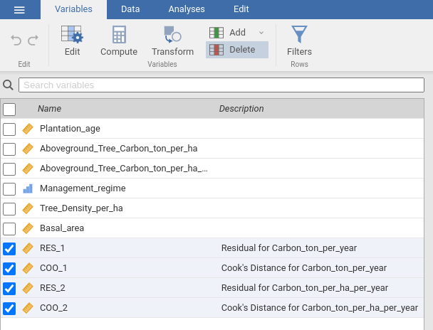

   remove columns

3. Go to the “Data” tab and change the “Plantation_age” data/ measure type to “*ordinal*” via the “Setup” button.

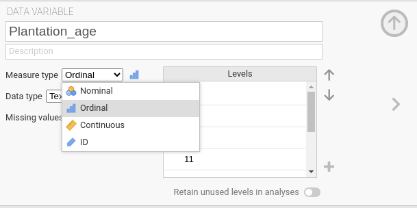

4. Navigate to the “Analyses” tab and from the “Exploration” button select “Descriptives”. Use the functions from this window to explore the data set.

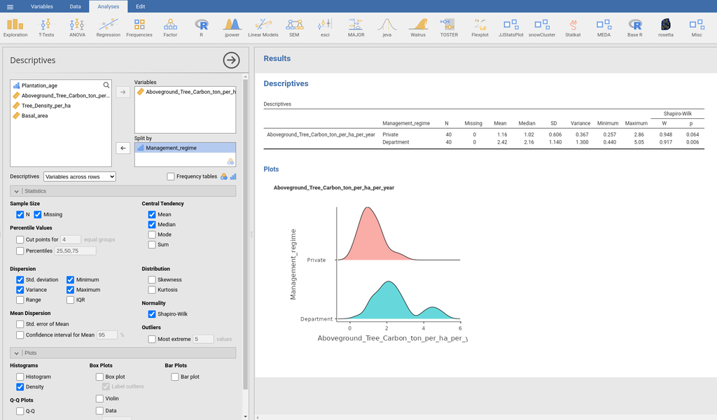

5. You can further perform data exploration visually. Select the “scatterplot” from the “Exploration” button and insert the appropriate variables to generate a scatterplot with linear fits along with density plots.

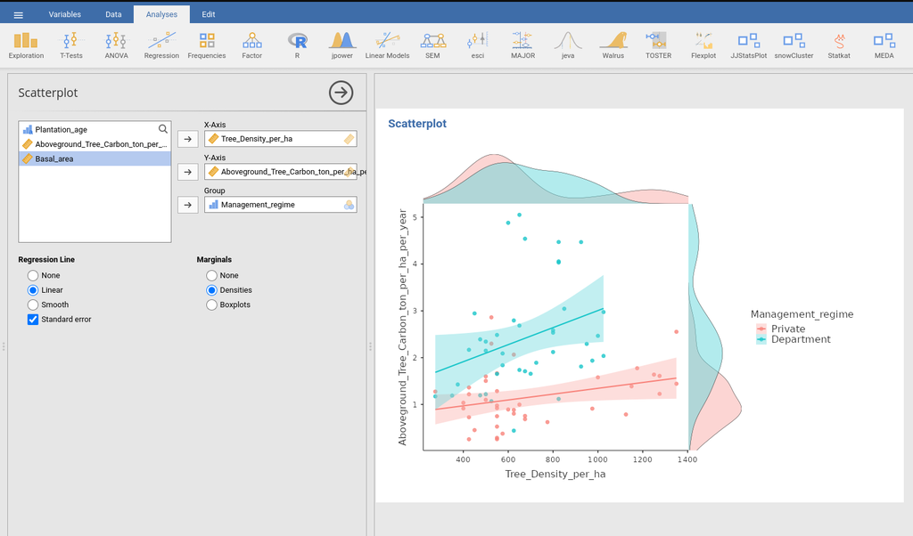

6. You can also perform correlation test including other statistical tests.

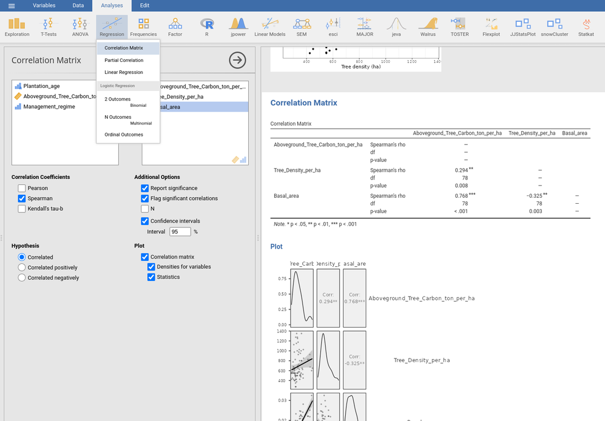

## 4.2 Performing hypothesis test in Jamovi

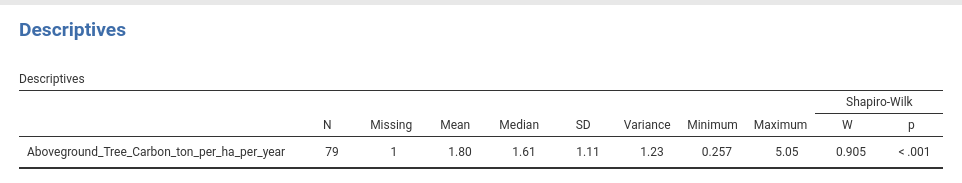

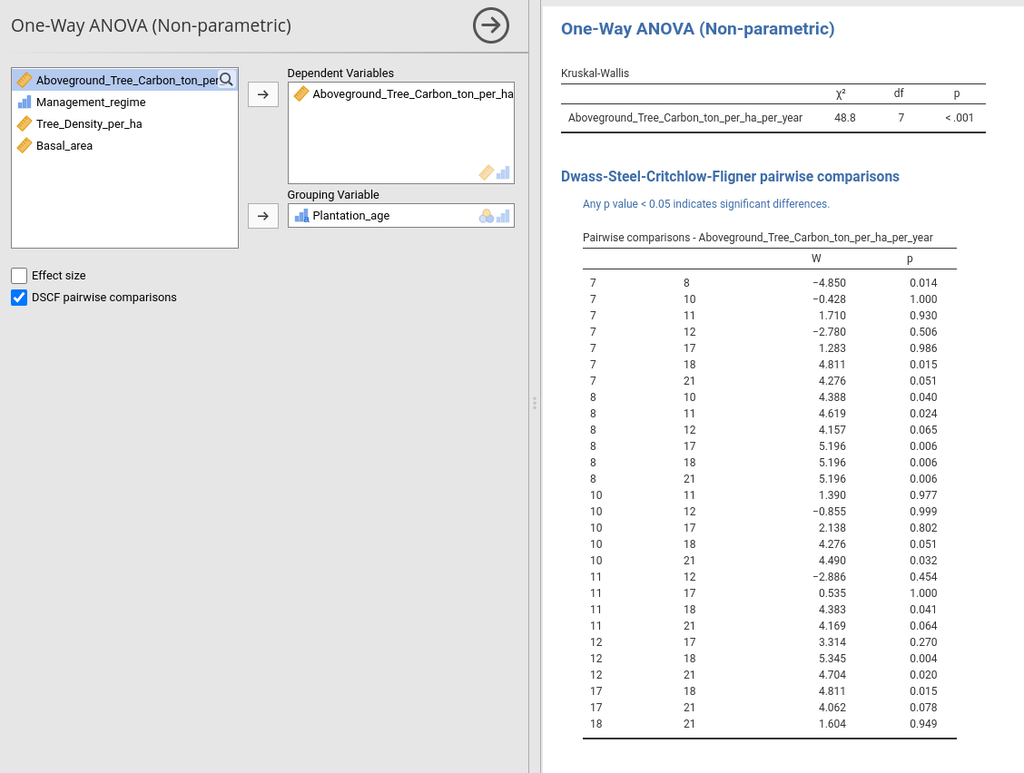

6. **Visualizing Results**: To provide a more intuitive understanding, we employ box plots as a visual aid. These plots vividly display the variations in above-ground tree carbon content across different plantation ages, enhancing our ability to interpret and communicate the findings.

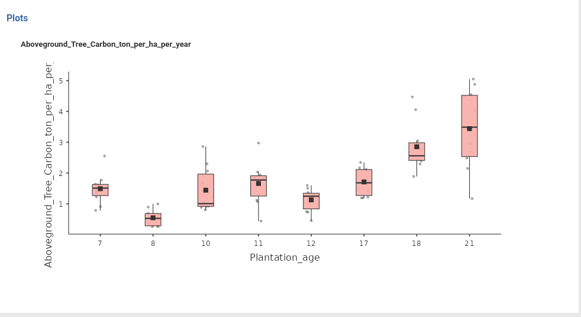

# 5 Software Integration

**Jamovi**, a user-friendly and open-source statistical analysis software, offers an interface that seamlessly integrates with **R**, a powerful programming language and environment for statistical computing. This integration combines the user-friendly features of Jamovi with the robust statistical capabilities of R, providing a flexible platform for data analysis and visualization.

Key points to consider in integrating R in Jamovi:

1. **Enhanced Statistical Power**: Jamovi’s integration with R allows users to access a wide range of advanced statistical techniques and methods available in the R ecosystem. This includes specialized packages for complex data analysis and modeling.
2. **Interactive Analysis**: Users can perform analyses in Jamovi using its point-and-click interface while observing the R syntax generated in real-time. This helps users learn and understand the R code associated with their analyses.
3. **Customization and Automation**: For users familiar with R, the integration enables seamless customization and automation of analyses. R users can extend analyses conducted in Jamovi with additional scripting and package integration.
4. **Data Visualization**: R’s data visualization capabilities are available within Jamovi, allowing users to create custom plots and charts for data exploration and presentation.
5. **Statistical Reporting**: Users can generate reports in Jamovi, including statistical summaries, tables, and visualizations, which can be customized and exported for publication or sharing.
6. **Collaboration**: Teams with varying levels of statistical expertise can collaborate effectively. Users can share Jamovi projects with colleagues, even if they are not R proficient, ensuring consistent analyses and results.
7. **Learning Opportunity**: For those new to R, Jamovi serves as a valuable learning tool. Users can explore the R code generated by Jamovi, helping them transition to more extensive R-based analyses.

In essence, integrating R in Jamovi offers a powerful combination of user-friendly statistical analysis and the versatility of R scripting. It caters to both beginners and experienced statisticians, making it an ideal choice for data analysis, research, and collaboration across diverse domains.

## 5.1 R as a Backend for Jamovi

1. **R as a Backend:** Jamovi, a user-friendly statistical analysis software, uses R as its computational backend. This means that when you perform statistical analyses or create plots in Jamovi, the software generates and executes corresponding R code in the background. This allows users who may not be familiar with R to take advantage of its powerful statistical capabilities.
2. **Point-and-Click Interface:** Jamovi provides a point-and-click interface for performing statistical analyses. Users can easily import datasets, perform various statistical tests, create visualizations, and generate reports without writing any R code.
3. **Real-Time Syntax Generation:** One of the key features of Jamovi is its ability to generate R syntax in real-time. As you perform actions in the Jamovi interface, such as running a t-test or creating a scatterplot, the corresponding R code is displayed. This provides users with a learning opportunity to understand the R commands associated with the analysis.
4. **Easy Transition to R:** For users who want to transition to R or have specific customization needs, Jamovi simplifies the process. Users can copy the generated R syntax from Jamovi and use it directly in their R environment for further customization or scripting.

## 5.2 **Integration of Jamovi in R**

1. **R Packages for Jamovi:** R users can take advantage of the “jmv” package, which allows them to interact with Jamovi directly from their R environment. This package provides functions to load Jamovi analyses, extract results, and incorporate Jamovi analyses into R scripts.
2. **Seamless Collaboration:** Researchers or data analysts who prefer R can still collaborate effectively with colleagues or team members using Jamovi. They can create their analyses in Jamovi, export the results as datasets, and then use R for advanced statistical modeling or further data manipulation.
3. **Customization:** R users can customize and extend the functionality of Jamovi analyses using R packages and scripts. This allows for greater flexibility and advanced data analysis when needed.
4. **Leveraging the Best of Both Worlds:** The integration of Jamovi in R and R in Jamovi offers the best of both worlds. Users can enjoy the simplicity and user-friendly interface of Jamovi for routine analyses while harnessing the extensive statistical and data manipulation capabilities of R when required.

The integration of R in Jamovi and Jamovi in R provides users with a flexible and powerful ecosystem for conducting statistical analyses. It accommodates users of varying skill levels, from those who prefer a graphical interface to those who are experienced R users, facilitating effective collaboration and streamlined workflows in data analysis and research.

## 5.3 Setting up R Syntax Mode in Jamovi

Setting up R Syntax mode in Jamovi allows users to harness the full power of R programming within Jamovi’s user-friendly interface. This mode enables users to write, execute, and customize R code seamlessly while taking advantage of Jamovi’s data visualization and analysis features. Here’s how to set up R Syntax mode in Jamovi:

1. **Install Jamovi**: If you haven’t already, download and install Jamovi on your computer from the official Jamovi website ([**https://www.jamovi.org/download.html**](https://www.jamovi.org/download.html)).
2. **Launch Jamovi**: Open Jamovi and create or open a dataset for analysis. You’ll typically start in the default point-and-click mode.
3. **Enable R Syntax Mode**:
   - Navigate to the far end right corner of Jamovi window and click on the three vertical dots.

   - From the drop-down menu, select “R Syntax Mode.” This action switches your analysis interface to R Syntax mode.

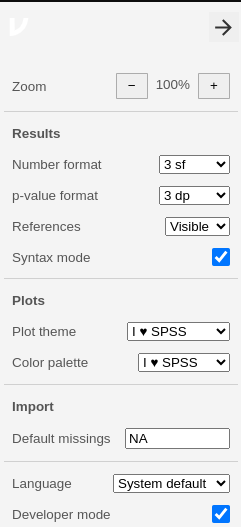

     Syntax mode

4. **R Syntax Mode**: Once you enable R Syntax Mode, you’ll notice that for any analysis or plotting, R codes will appear next to the results.

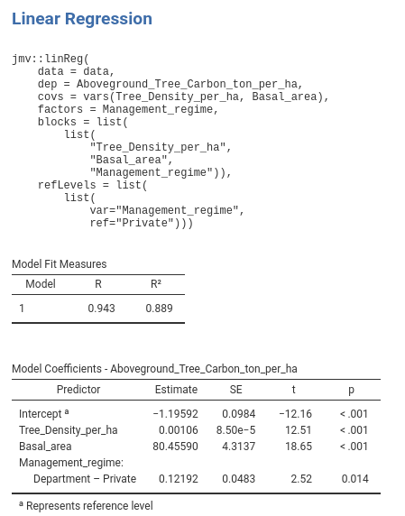

   syntax

5. **Writing R Code in Jamovi**:
   - You can write and execute R codes directly from within Jamovi’s R editor. This is a module which is called “Rj” and can be accessed from the modules library. It must be installed and pinned to the main menu.

[figure not shown]

     Rj module

   - Click on the “Rj” icon and select “Rj editor”.

[figure not shown]

     rj editor

   - You can start writing R code directly in the console. For example, you can create variables, perform data manipulations, run statistical analyses, and create visualizations using R syntax. Examples are shown below.

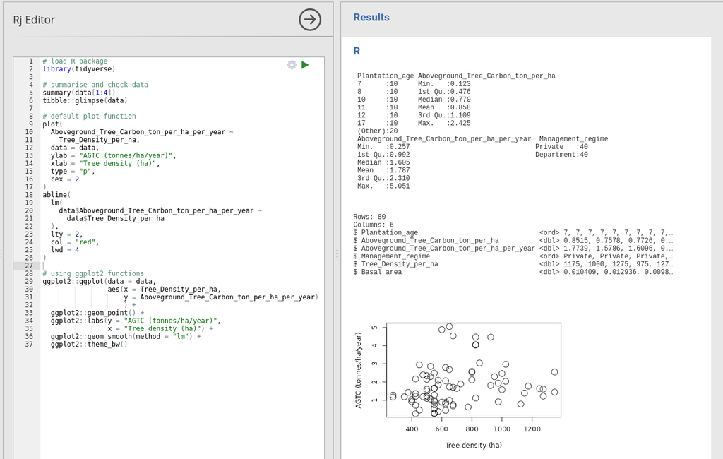

     codes in Rj editor

6. **Running R Code**: To execute the R code you’ve written, simply press the “Run” button in the R Syntax Console or use the shortcut (typically Ctrl+Shift+Enter or Cmd+Shift+Enter).
7. **Output and Visualizations**: As you execute R code, any output, plots, or results will be displayed within the console. You can also create custom visualizations using R packages like ggplot2.
8. **Combining Point-and-Click and R**: Jamovi’s unique feature allows you to switch between Point-and-Click mode and R Syntax mode seamlessly. You can start with a point-and-click analysis and switch to R Syntax mode to access advanced options and customization.
9. **Saving and Sharing**: You can save your Jamovi project, which includes your dataset, analyses, and R code. This makes it easy to share your work or collaborate with others.

[figure not shown]

   save project or workspace (.omv)

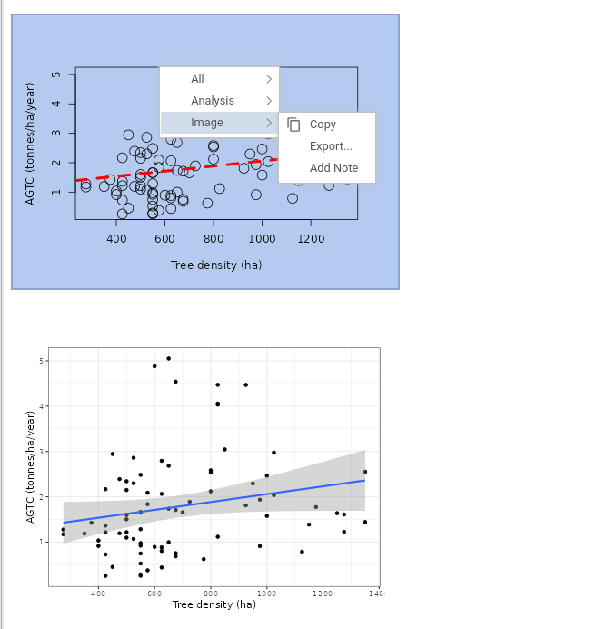

   copy plots or results

10. **Learning Resources**: If you’re new to R, there are plenty of online resources and tutorials available to help you learn R programming within Jamovi. Additionally, the generated R code can serve as a valuable learning tool.

Setting up R Syntax mode and Rj editor module in Jamovi empowers users to perform complex analyses and customizations, making it a versatile tool for both beginners and experienced data analysts and researchers. It combines the accessibility of Jamovi with the flexibility of R, offering the best of both worlds for data analysis and visualization.

## 5.4 Example:

### 5.4.1 Plotting

1. Create a scatter-plot. The syntax should automatically be included in the result section along with plot. Right-click on the syntax area and select syntax to copy for use in R.

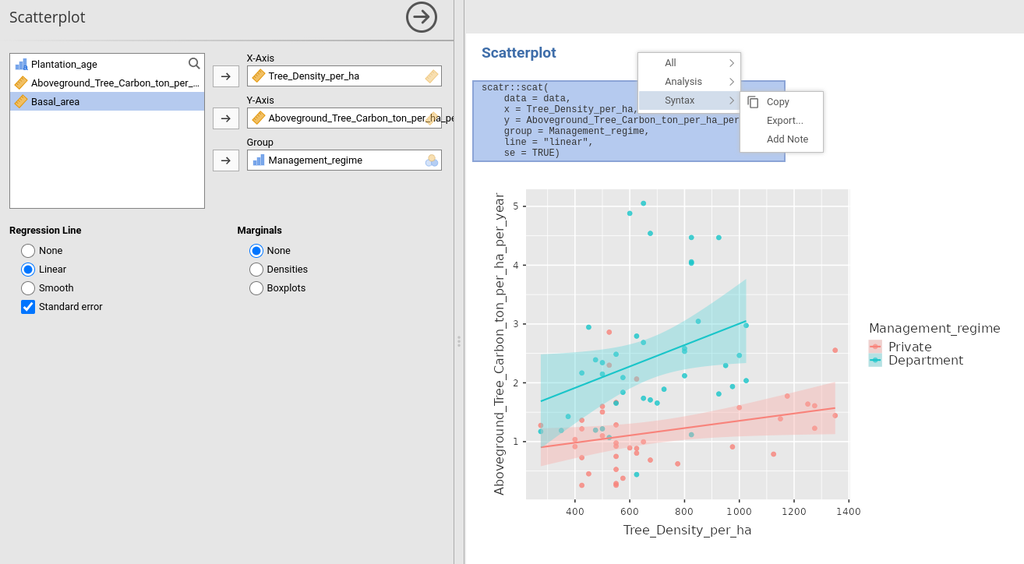

2. In R, install and load the following packages: **`jmv`** and **`scatr`**. Furthermore, import the data set into R, paste the syntax copied over from Jamovi and run the syntax as shown below.

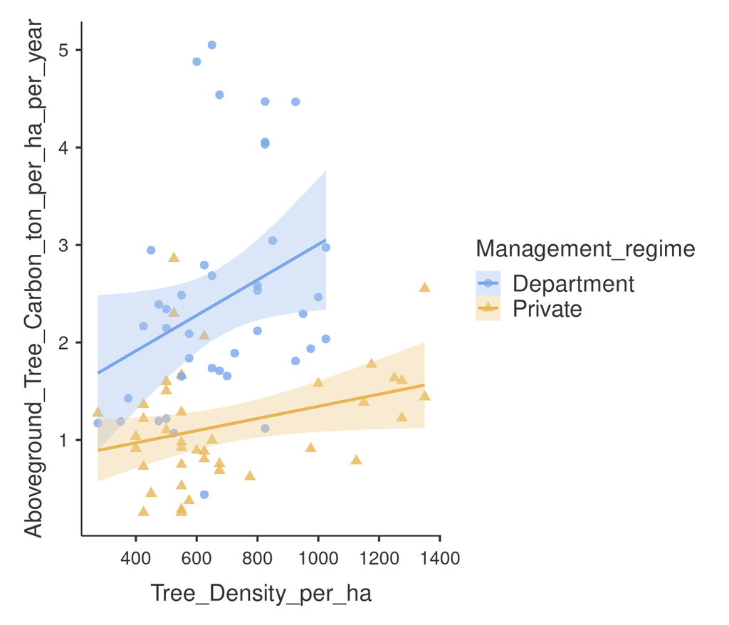

```r
# Use pacman::p_load to load packages (jmv, scatr, jmvcore)
# with optional installation and no package updates
pacman::p_load(jmv, scatr, jmvcore, install = TRUE, update = FALSE)

# Import above-ground carbon data from a CSV or the SAV file
carbon <- readr::read_csv("./data/Filtered.csv")
carbon_spss_data <- haven::read_sav("./data/Filtered.sav")

# Syntax from the scatr package to create a scatterplot with linear regression lines
# This code visualizes the relationship between Tree Density, Aboveground Carbon, and Management Regime
scatr::scat(
    data = carbon,                                           # Specify the dataset (carbon)
    y = "Aboveground_Tree_Carbon_ton_per_ha_per_year",      # Choose the dependent variable (Y-axis)
    x = "Tree_Density_per_ha",                              # Choose the independent variable (X-axis)
    group = "Management_regime",                            # Group the data by Management Regime
    line = "linear",                                        # Add linear regression lines
    se = TRUE)                                              # Display standard error bars
```

**R Code Explanation:**

- **`pacman::p_load(jmv, scatr, jmvcore, install = TRUE, update = FALSE)`** is used to load three packages: **`jmv`**, **`scatr`**, and **`jmvcore`**. The **`install = TRUE`** parameter ensures that these packages are installed if they are not already installed, and **`update = FALSE`** prevents the packages from being updated.
- **`carbon <- readr::read_csv("./data/Filtered.csv")`** reads data from a CSV file named “Filtered.csv” located in the “./data” directory and stores it in a variable called “carbon.” This line imports the dataset needed for further analysis.
- **`scatr::scat(...)`** is a function from the **`scatr`** package used to create a scatterplot with linear regression lines. The code specifies the dataset as “carbon,” sets the Y-axis variable to “Aboveground_Tree_Carbon_ton_per_ha_per_year,” sets the X-axis variable to “Tree_Density_per_ha,” groups the data by “Management_regime,” adds linear regression lines, and displays standard error bars. This code is used to visualize the relationship between Tree Density, Aboveground Carbon, and Management Regime in the dataset.

Note that plots created using the `scatr` package has limited functions to further tweak plots. A work around for this issue is to use the `ggplot2` package which has more customizable functions. An example is shown below.

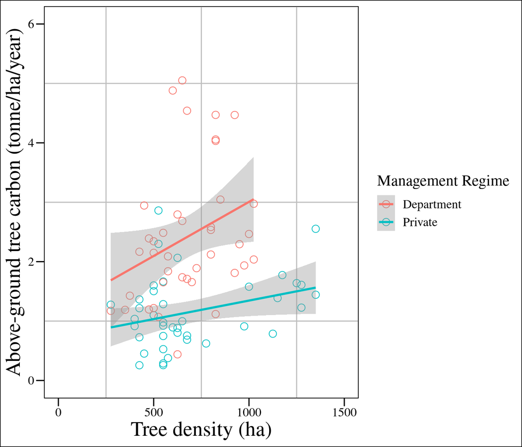

```r
# Use pacman::p_load to load packages (ggthemes, ggplot2, patchwork)
# with optional installation and no package updates
pacman::p_load(ggthemes,
               ggplot2,
               patchwork,
               install = TRUE,
               update = FALSE)

# Import dataset from a CSV file
carbon <- readr::read_csv("./data/Filtered.csv")

# Create a customizable plot using ggplot2
plot1 <- ggplot2::ggplot(
  data = carbon,                                             # Specify the dataset (carbon)
  aes(                                                       # Define aesthetic mappings
    x = carbon$Tree_Density_per_ha,                         # X-axis variable
    y = carbon$Aboveground_Tree_Carbon_ton_per_ha_per_year,  # Y-axis variable
    col = carbon$Management_regime                           # Color by Management Regime
  )
) +
  ggplot2::geom_point(size = 3, pch = 21) +                  # Add points with custom size and shape
  ggplot2::geom_smooth(method = "lm") +                      # Add a linear regression line
  ggplot2::labs(x = "Tree density (ha)",                    # Set X-axis label
                y = "Above-ground tree carbon (tonne/ha/year)", # Set Y-axis label
                col = "Management Regime") +                 # Set legend title
  ggplot2::scale_x_continuous(limits = c(0, 1500)) +         # Set X-axis limits
  ggplot2::scale_y_continuous(limits = c(0, 6)) +            # Set Y-axis limits
  ggthemes::theme_base(base_size = 15, base_family = "times") +  # Apply custom theme settings
  ggplot2::theme(
    panel.grid.minor = element_line(size = 0.5, color = "grey"), # Customize minor grid lines
    axis.title = element_text(size = 20)                      # Customize axis title text
  )

# Print the customized plot
print(plot1)
```

**R Code Explanation:**

- **`pacman::p_load(...)`** is used to load three packages: **`ggthemes`**, **`ggplot2`**, and **`patchwork`**. The **`install = TRUE`** parameter ensures that these packages are installed if they are not already installed, and **`update = FALSE`** prevents the packages from being updated.
- **`carbon <- readr::read_csv("./data/Filtered.csv")`** reads data from a CSV file named “Filtered.csv” located in the “./data” directory and stores it in a variable called “carbon.” This line imports the dataset needed for plotting.
- The **`ggplot2::ggplot(...)`** function is used to create a customizable plot. It specifies the dataset as “carbon” and defines aesthetic mappings, including X-axis, Y-axis, and color mapping based on the “Management_regime” column.
- Various **`ggplot2::geom_`** functions are used to add geometrical elements to the plot, such as points and a linear regression line.
- **`ggplot2::labs(...)`**, **`ggplot2::scale_...`**, and **`ggthemes::theme_...`** functions are used to customize plot labels, axis limits, and theme settings.
- Finally, **`print(plot1)`** prints the customized plot to the output.

### 5.4.2 Combine multiple plots

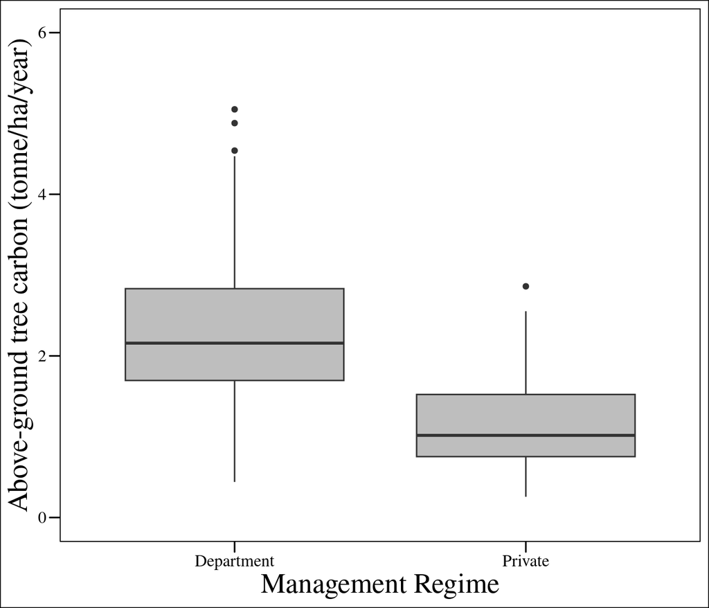

```r
# Modify the first plot (plot1)
p1 <- plot1 +
  ggplot2::labs(x = "Tree density (ha)",         # Change the X-axis label
                y = "Above-ground tree carbon (tonne/ha/year)",  # Change the Y-axis label
                col = "")                         # Remove the color legend title

# Create another customizable plot using ggplot2
plot2 <- ggplot2::ggplot(
  data = carbon,                                           # Specify the dataset (carbon)
  aes(
    x = carbon$Management_regime,                         # X-axis variable
    y = carbon$Aboveground_Tree_Carbon_ton_per_ha_per_year  # Y-axis variable
  )
) +
  ggplot2::geom_boxplot(fill = "grey") +                  # Add a boxplot with grey fill
  ggplot2::labs(x = "Management Regime",                  # Set X-axis label
                y = "Above-ground tree carbon (tonne/ha/year)") +  # Set Y-axis label
  ggplot2::scale_y_continuous(limits = c(0, 6)) +         # Set Y-axis limits
  ggthemes::theme_base(base_size = 15, base_family = "times") +  # Apply custom theme settings
  ggplot2::theme(axis.title = element_text(size = 20))     # Customize axis title text

# Print the second plot (plot2)
print(plot2)
```

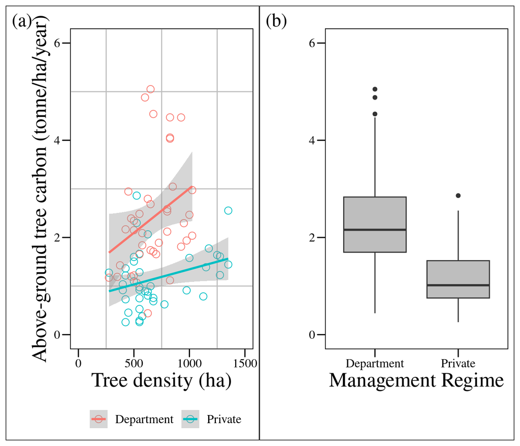

```r
# Modify the second plot (plot2)
p2 <- plot2 + ggplot2::labs(x = "Management Regime",   # Change the X-axis label
                            y = "")                    # Remove the Y-axis label

# Combine both modified plots (p1 and p2) using the "&" operator
# Also, customize the legend position and add plot annotations
p1 + p2 &
  theme(
    legend.position = "bottom"                           # Customize legend position
  ) &
  patchwork::plot_annotation(
    tag_levels = "a", tag_prefix = "(", tag_suffix = ")"  # Add plot annotations with tags
  )
```

**R Code Explanation:**

- **`p1`** is created by modifying **`plot1`**. The X-axis label is changed, and the color legend title is removed.
- **`plot2`** is created as a new customizable plot using **`ggplot2`**. It specifies the dataset and aesthetic mappings, creates a box-plot, and customizes the plot labels, axis limits, and theme settings.
- **`p2`** is created by modifying **`plot2`**. The X-axis label is changed, and the Y-axis label is removed.
- **`p1 + p2 & ...`** combines both modified plots **`p1`** and **`p2`** using the **`&`** operator. Additional customizations are applied to the combined plot, including changing the legend position and adding plot annotations with tags.

### 5.4.3 Analyses Syntax

The following syntax and results (image) below were generated in Jamovi. Syntax is further modified in R.

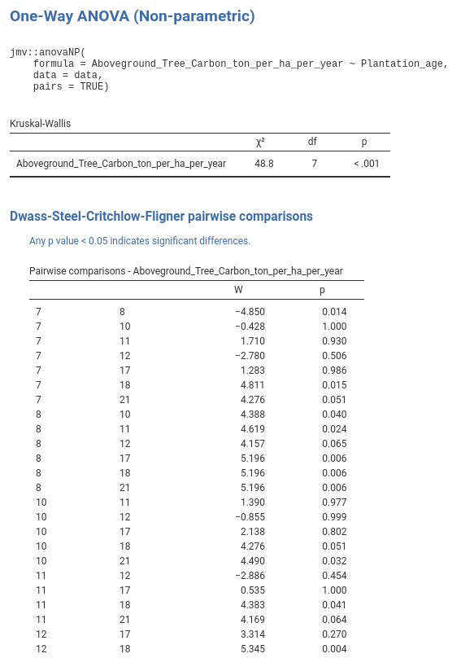

Analysis syntax and results from Jamovi.

```r
# Load necessary R packages using pacman
pacman::p_load(jmv,          # Load the jmv package for statistical analysis
               magrittr,     # Load the magrittr package for data manipulation
               install = TRUE,  # Install packages if not already installed
               update = FALSE   # Do not update packages if newer versions are available
)

# Perform Kruskal-Wallis test with pairwise comparisons
kruskal_pairwise <- jmv::anovaNP(
    formula = Aboveground_Tree_Carbon_ton_per_ha_per_year ~ Plantation_age,  # Specify the formula
    data = carbon,                        # Specify the dataset (carbon)
    pairs = TRUE                          # Perform pairwise comparisons
)

# Display the Kruskal-Wallis significance test results
kruskal_pairwise %>% print()
```

```
##
##  ONE-WAY ANOVA (NON-PARAMETRIC)
##
##  Kruskal-Wallis
##  ───────────────────────────────────────────────────────────────────────────────
##                                                   χ²          df    p
##  ───────────────────────────────────────────────────────────────────────────────
##    Aboveground_Tree_Carbon_ton_per_ha_per_year    50.05889     7    < .0000001
##  ───────────────────────────────────────────────────────────────────────────────
##
##
##  DWASS-STEEL-CRITCHLOW-FLIGNER PAIRWISE COMPARISONS
##
##  Pairwise comparisons - Aboveground_Tree_Carbon_ton_per_ha_per_year
##  ──────────────────────────────────────────────────────────────────
##                W             p
##  ──────────────────────────────────────────────────────────────────
##    7     8     -5.0245113    0.0091010
##    7     10    -0.4276180    0.9999889
##    7     11     1.7104719    0.9296347
##    7     12    -2.7795169    0.5055258
##    7     17     1.2828540    0.9855155
##    7     18     4.8107024    0.0154435
##    7     21     4.2761799    0.0511307
##    8     10     4.5968934    0.0254800
##    8     11     4.7037979    0.0199077
##    8     12     4.0623709    0.0783341
##    8     17     5.3452248    0.0039229
##    8     18     5.3452248    0.0039229
##    8     21     5.3452248    0.0039229
##    10    11     1.3897585    0.9769915
##    10    12    -0.8552360    0.9988368
##    10    17     2.1380899    0.8016074
##    10    18     4.2761799    0.0511307
##    10    21     4.4899889    0.0323768
##    11    12    -2.8864214    0.4543784
##    11    17     0.5345225    0.9999489
##    11    18     4.3830844    0.0408393
##    11    21     4.1692754    0.0635316
##    12    17     3.3140394    0.2701716
##    12    18     5.3452248    0.0039229
##    12    21     4.7037979    0.0199077
##    17    18     4.8107024    0.0154435
##    17    21     4.0623709    0.0783341
##    18    21     1.6035675    0.9494883
##  ──────────────────────────────────────────────────────────────────
```

**R Code Explanation:**

- **`pacman::p_load(...)`** is used to load the required R packages, including **`jmv`** for statistical analysis and **`magrittr`** for data manipulation. The **`install`** parameter is set to **`TRUE`** to install the packages if they are not already installed, and **`update`** is set to **`FALSE`** to prevent updating packages.
- **`kruskal_pairwise`** stores the result of the Kruskal-Wallis test with pairwise comparisons. It calculates the Kruskal-Wallis test for the specified formula and dataset, and the **`pairs = TRUE`** argument indicates that pairwise comparisons should be performed.
- **`kruskal_pairwise %>% print()`** is used to display the Kruskal-Wallis significance test results directly without the need to extract them into a data frame.

# 6 Resources

1. [R for Data Science](https://r4ds.had.co.nz/)
2. [GGPlot2 Book](https://ggplot2-book.org/)
3. [R Packages](https://r-pkgs.org/)
4. [Learning statistics with jamovi](https://davidfoxcroft.github.io/lsj-book/03-Getting-started-with-jamovi.html#analyses)
5. [Basic statistical tests using rstatix package](https://github.com/kassambara/rstatix)

# 7 Supplementary Information

## 7.1 **Hypothesis Testing: Parametric and Non-Parametric Tests**

*Understanding the Foundations of Statistical Testing*

### 7.1.1 **Importance of Hypothesis Testing in Forestry and Ecology**

Hypothesis testing plays a pivotal role in the fields of forestry and ecology, offering invaluable insights into various aspects of environmental and ecological research. This statistical methodology allows researchers to systematically investigate hypotheses, evaluate the validity of theories, and draw meaningful conclusions based on empirical evidence. Below, we delve into the significance of hypothesis testing in forestry and ecology:

1. **Validating Theories:** Forestry and ecology encompass a wide range of complex theories and models that describe the behavior of ecosystems, species, and natural resources. Hypothesis testing provides a rigorous framework to assess the accuracy of these theories by comparing predicted outcomes to observed data. Researchers can confirm whether their theoretical predictions align with real-world observations, enhancing the credibility of their work.
2. **Informed Decision-Making:** In both forestry and ecology, critical decisions are made concerning the management of natural resources, conservation efforts, and environmental policies. Hypothesis testing allows researchers to collect and analyze data systematically, providing a scientific basis for these decisions. For example, hypotheses about the effects of specific management practices on forest regeneration can guide forest management strategies.
3. **Environmental Impact Assessment:** Understanding the influence of environmental factors on ecosystems and species is fundamental in ecology. Hypothesis testing enables scientists to investigate how variables such as temperature, precipitation, pollution, or habitat loss affect ecological systems. This information is crucial for assessing environmental impacts, predicting trends, and implementing measures to mitigate negative consequences.
4. **Species Conservation:** Conservation biology is a vital component of ecology. Hypothesis testing aids in assessing the success of conservation efforts and understanding the factors influencing endangered species. Researchers can formulate hypotheses related to the effectiveness of conservation strategies, such as habitat restoration or captive breeding programs, and rigorously test these hypotheses through data analysis.
5. **Biodiversity Studies:** Hypothesis testing is instrumental in biodiversity studies. Ecologists can develop hypotheses about the factors contributing to biodiversity, including species interactions, habitat diversity, and environmental conditions. Through hypothesis testing, researchers can identify key drivers of biodiversity patterns and develop strategies to protect and preserve diverse ecosystems.

Hypothesis testing is an indispensable tool in forestry and ecology, providing researchers with a structured approach to explore and validate theories, make informed decisions, assess environmental impacts, conserve species, and study biodiversity. By subjecting hypotheses to rigorous statistical analysis, scientists contribute to a deeper understanding of the natural world and support evidence-based practices in these critical fields.

### 7.1.2 **Key Concepts**

#### 7.1.2.1 **Definition of Null and Alternative Hypotheses**

- **Null Hypothesis (H0):** The null hypothesis serves as the baseline assumption in hypothesis testing. It posits that there is no statistically significant difference or effect in the population under investigation. In the context of oak tree height, the null hypothesis (H0) could be framed as: “There is no significant difference in the average height of oak trees between Site A and Site B.” In essence, it suggests that any observed differences are due to random variation.
- **Alternative Hypothesis (H1):** The alternative hypothesis is the statement researchers seek to support. It proposes the existence of a significant difference, effect, or relationship within the population. For our example, the alternative hypothesis (H1) could be stated as: “There is a significant difference in the average height of oak trees between Site A and Site B.” This implies that the observed differences are not due to chance but are indeed meaningful.

#### 7.1.2.2 **Explanation of the Significance Level (Alpha)**

- **Significance Level (Alpha):** The significance level, often denoted as α (alpha), represents the threshold for statistical significance. In most research, it is set at 0.05 (5%). This value signifies the maximum acceptable probability of making a Type I error — wrongly rejecting the null hypothesis when it is true. In practical terms, it means that researchers are willing to tolerate a 5% chance of making this error.

#### 7.1.2.3 **Introducing p-values and Their Interpretation**

- **p-value:** The p-value quantifies the evidence against the null hypothesis. It represents the probability of obtaining observed results, or more extreme results, when the null hypothesis is true. A low p-value suggests that the observed data is unlikely to have occurred by random chance alone.
- **Interpretation of p-values:** In our example, a p-value of 0.03 indicates that there’s a 3% probability that the observed difference in oak tree heights between Site A and Site B occurred due to random chance. Since this probability (3%) is less than the significance level (5%), we would typically reject the null hypothesis in favor of the alternative hypothesis, suggesting a significant difference.

**Type I and Type II Errors**

- **Type I Error:** In ecology, a Type I error could have significant consequences. It occurs when researchers incorrectly identify a species as invasive when it is not. This could lead to unwarranted and potentially costly eradication efforts or management strategies.
- **Type II Error:** Conversely, a Type II error in ecology might involve failing to detect a critically endangered species when it does exist. This error could result in the inadequate protection of a vulnerable species and its habitat.

In summary, understanding null and alternative hypotheses, the significance level (alpha), p-values, and the potential for Type I and Type II errors is crucial in ecological research. These concepts guide researchers in making informed decisions about the validity of their findings and the implications for conservation, species identification, and ecosystem management.

### 7.1.3 **Parametric vs. Non-Parametric Tests**

#### 7.1.3.1 **Difference between Parametric and Non-Parametric Tests**

- **Parametric Tests:** Parametric tests make specific assumptions about the distribution of data, often assuming it follows a normal distribution. These tests rely on parameters like means and variances.
- **Non-Parametric Tests:** Non-parametric tests, on the other hand, are distribution-free and do not rely on specific assumptions about the data distribution. They are more robust when data deviates from normality or when dealing with ordinal or non-continuous data.

#### 7.1.3.2 **Examples in Forestry and Ecology**

- **Parametric Example:** Testing if there’s a difference in the mean chlorophyll levels between two groups of plant species. Here, you might assume that chlorophyll levels follow a normal distribution.
- **Non-Parametric Example:** Comparing the diversity of aquatic invertebrate species in different river habitats. Since species diversity may not follow a normal distribution, a non-parametric test is more appropriate.

#### 7.1.3.3 **Parametric Tests**

##### 7.1.3.3.1 **When to Use Parametric Tests**

Parametric tests are appropriate when data is normally distributed and meets the assumptions of the specific test being used. These tests tend to be more powerful when assumptions are met.

##### 7.1.3.3.2 **Common Parametric Tests with Forestry/Ecology Examples:**

- **t-test:** Use a t-test when comparing the mean annual precipitation in two different forest ecosystems. This test assesses if the means of two groups are significantly different.
- **ANOVA (Analysis of Variance):** ANOVA is suitable for assessing if there’s a significant difference in bird species richness among three different forest types. It can compare means across multiple groups.
- **Linear Regression:** Linear regression is ideal for investigating the relationship between temperature and tree growth in a specific forest region. It models the relationship between two continuous variables.

#### 7.1.3.4 **Non-Parametric Tests**

##### 7.1.3.4.1 **When to Use Non-Parametric Tests**

Non-parametric tests should be employed when data doesn’t meet parametric assumptions, such as non-normality, or when dealing with ordinal or ranked data.

##### 7.1.3.4.2 **Common Non-Parametric Tests with Forestry/Ecology Examples**

- **Mann-Whitney U Test:** Use this test to compare the diversity of fungi species in two different soil types. It assesses if there’s a difference in the distribution of values between two groups.
- **Kruskal-Wallis Test:** When you want to test if there’s a difference in plant height across various altitudinal zones, the Kruskal-Wallis test is suitable. It’s a non-parametric alternative to ANOVA for multiple groups.
- **Wilcoxon Signed-Rank Test:** Assess changes in insect abundance before and after a controlled burn in a grassland ecosystem. This non-parametric test is used for paired data to determine if the medians are different.

Understanding the choice between parametric and non-parametric tests is essential in forestry and ecology research. Parametric tests make specific assumptions about data distribution, while non-parametric tests are more flexible and suitable when assumptions are not met or when dealing with non-continuous data. The choice of test should align with the nature of the data and the research question.

### 7.1.4 **Considerations for Choosing Between Parametric and Non-Parametric Tests in Forestry and Ecology**

1. **Data Characteristics**
   - **Normality:** If your data follows a normal distribution and meets the assumptions of parametric tests, then parametric tests can provide more statistical power. Ensure you check normality using tools like normal probability plots or Shapiro-Wilk tests.
   - **Data Type:** Consider the type of data you have. Parametric tests are designed for continuous, interval, or ratio data. Non-parametric tests can handle ordinal or ranked data and are robust to outliers.
2. **Sample Size**
   - **Large Samples:** Parametric tests tend to perform well with larger sample sizes. If you have a substantial amount of data, parametric tests may detect even small differences.
   - **Small Samples:** In cases with small sample sizes, non-parametric tests can be more appropriate. They are less sensitive to outliers and deviations from normality.
3. **Research Questions**
   - **Nature of Comparison:** The nature of your research question matters. If you’re comparing means or conducting regression analysis, parametric tests are common. For comparing distributions or medians, non-parametric tests are often preferred.
   - **Experimental Design:** The design of your study, such as whether it’s a repeated-measures design or an independent measures design, can influence test choice. Some tests, like the paired t-test, are parametric and have non-parametric counterparts.
4. **Assumptions**
   - **Assumption Check:** Always check the assumptions of parametric tests, such as normality and homogeneity of variances. If assumptions are violated, consider non-parametric alternatives.
5. **Robustness**
   - **Robustness to Outliers:** Non-parametric tests are less affected by outliers. If your data includes extreme values, non-parametric tests may provide more reliable results.
6. **Type of Data Analysis**
   - **Regression:** If you’re conducting regression analysis, parametric linear regression models are widely used. Non-parametric regression techniques, like kernel regression, exist but are less common.
7. **Statistical Power**
   - **Statistical Power:** Consider the balance between statistical power and assumptions. Parametric tests tend to have higher power when assumptions are met, but lower power when assumptions are violated.
8. **Interpretability**
   - **Interpretability:** Think about the ease of interpretation. Parametric tests often provide straightforward interpretations, such as differences in means. Non-parametric tests may yield results that are less intuitive to interpret.
9. **Data Transformations**
   - **Data Transformations:** If your data doesn’t meet parametric assumptions, consider data transformations to achieve normality. However, be cautious with transformations, as they can impact interpretation.

The choice between parametric and non-parametric tests in forestry and ecology should be driven by a thorough understanding of your data, research questions, and assumptions. While parametric tests offer higher power under specific conditions, non-parametric tests provide robustness when assumptions are in doubt. It’s essential to carefully consider these factors to make informed decisions about test selection in your research.

### 7.1.5 **Practical Example**

#### 7.1.5.1 **Comparing Canopy Cover in Logged and Old-Growth Forests**

- **Research Question:** Does the average tree canopy cover differ significantly between a logged forest and an old-growth forest?
- **Data:** Canopy cover measurements from both forest types.
- **Hypotheses:**
  - **Null Hypothesis (H0):** There is no difference in canopy cover between the logged forest and the old-growth forest.
  - **Alternative Hypothesis (H1):** There is a significant difference in canopy cover between the logged forest and the old-growth forest.
- **Steps to Analyze:**
1. **Data Collection:** Gather canopy cover measurements for both the logged and old-growth forests. Ensure that the data is properly recorded and labeled.
2. **Data Inspection:** Start by inspecting the data. Plot histograms or density plots to assess data distribution. You may use tools in R or Jamovi for this purpose.
3. **Choosing the Test:** Based on the data distribution:
   - If the data follows a normal distribution and meets the assumptions (check using normality tests), you can perform a **t-test**.
   - If the data does not meet the assumptions of normality, consider a **Mann-Whitney U test** (a non-parametric alternative).
4. **Perform the Test:**
   - In R: Use the **`t.test()`** function for the t-test or **`wilcox.test()`** function for the Mann-Whitney U test.
   - In Jamovi: You can use the point-and-click interface to perform these tests. Import your data and choose the appropriate test based on data distribution.
5. **Interpret Results:**
   - For the t-test, examine the p-value. If it is less than your chosen significance level (typically 0.05), you would reject the null hypothesis. This suggests that there is a significant difference in canopy cover between the logged and old-growth forests.
   - For the Mann-Whitney U test, similarly look at the p-value. A p-value below 0.05 indicates a significant difference in canopy cover.
6. **Effect Size:** Consider calculating and reporting the effect size. For example, in a t-test, Cohen’s d is a commonly used measure of effect size.
7. **Conclude:** Based on the results, draw a conclusion regarding whether there is a significant difference in canopy cover between the two forest types.
8. **Report:** Document your findings in a clear and concise manner, including any visualizations and statistical details. Mention the test used, the p-value, and the effect size.
9. **Discussion:** Discuss the implications of your findings for forestry and ecology. Consider how this information can contribute to the understanding of forest ecosystems or conservation efforts.

Remember that the choice between the t-test and Mann-Whitney U test depends on the data distribution and assumptions. Always verify the assumptions before selecting the appropriate test.

### 7.1.6 **Summary**

#### 7.1.6.1 **The Significance of Hypothesis Testing in Forestry and Ecology**

- **Hypothesis Testing’s Fundamental Role:** Hypothesis testing is a cornerstone of data analysis in forestry and ecology. It empowers researchers to make informed decisions, draw meaningful conclusions, and contribute to the understanding of ecological systems and forest management.
- **Data-Driven Decision Making:** In forestry and ecology, decisions regarding conservation efforts, ecosystem management, and environmental policy are often data-driven. Hypothesis testing provides a systematic approach to validate or refute hypotheses, which, in turn, guide these critical decisions.
- **Tailoring Tests to Data:** The choice of a hypothesis test is not arbitrary but depends on the specific characteristics of the data at hand. Researchers need to assess data distribution, sample size, and the nature of variables before selecting an appropriate statistical test.
- **The Crucial Role of Hypothesis Formulation:** The formulation of null and alternative hypotheses should be done with precision. It’s imperative to clearly articulate the research question and the expected outcomes in the hypotheses. Ambiguity in hypothesis formulation can lead to misinterpretation of results.
- **Critical Test Selection:** Selecting the right hypothesis test is pivotal. Whether it’s a parametric test like t-tests or ANOVA for normally distributed data, or non-parametric tests like Mann-Whitney U or Kruskal-Wallis for non-normally distributed data, making the correct choice ensures the reliability and validity of results.
- **Meaningful Results:** Correctly executed hypothesis testing yields meaningful results that can drive scientific discoveries, support evidence-based management practices, and contribute to the conservation of ecological systems.
- **Interdisciplinary Application:** The principles of hypothesis testing transcend disciplinary boundaries. Researchers in forestry and ecology can benefit from statistical rigor, ensuring that their findings are robust and actionable.
- **Continuous Learning:** As statistical methods and tools evolve, researchers should stay current with best practices in hypothesis testing. Ongoing education and collaboration with statisticians or data scientists can enhance the quality of research.
- **Ethical Considerations:** Sound hypothesis testing is not only about finding statistical significance; it also carries ethical implications. Responsible interpretation of results and transparent reporting are essential for maintaining scientific integrity.

In summary, hypothesis testing plays a pivotal role in advancing knowledge in forestry and ecology. It empowers researchers to rigorously assess hypotheses, make data-driven decisions, and contribute to the sustainable management of ecosystems and forests. Proper test selection and hypothesis formulation are essential to derive meaningful insights from data, fostering interdisciplinary collaboration and ethical scientific practice.

## 7.2 **Confidence Intervals, p-values Interpretation, and Correlation Test**

*Unraveling the Mysteries of Statistical Inference*

### 7.2.1 **The Significance of Confidence Intervals, p-Values, and Correlation Tests in Forestry and Ecology**

- **Informing Decision-Making:** These statistical concepts are critical tools that help researchers in forestry and ecology make informed decisions based on empirical evidence. They go beyond raw data and provide a framework for interpreting results.
- **Quantifying Uncertainty:** Confidence intervals are invaluable for quantifying uncertainty. In forestry and ecology, where ecosystems are inherently complex, it’s rarely possible to make definitive statements. Confidence intervals provide a range of plausible values, giving researchers and policymakers a clearer understanding of the uncertainty surrounding estimates.
- **Assessing Statistical Significance:** p-Values serve as a compass for researchers. They indicate the strength of evidence against the null hypothesis. In ecological studies, knowing whether an effect is statistically significant is essential for evaluating the ecological importance of a phenomenon.
- **Understanding Relationships:** Correlation tests, such as Pearson’s correlation coefficient or Spearman’s rank correlation, reveal relationships between variables. These relationships can be crucial in forestry for understanding the impact of environmental factors on tree growth or in ecology for studying predator-prey dynamics.
- **Robust Scientific Inference:** In forestry, when determining the effectiveness of a silvicultural practice, researchers must assess not only the magnitude of change but also its statistical significance. Similarly, in ecology, it’s not just about observing patterns but rigorously testing hypotheses about ecological interactions.
- **Supporting Conservation Efforts:** In ecology, understanding the correlation between environmental factors and species distribution can guide conservation efforts. For example, knowing the correlation between water quality and amphibian populations can inform wetland management practices.
- **Interpreting Ecological Data:** Ecology often deals with complex, noisy data. Confidence intervals and p-values help ecologists distinguish meaningful patterns from random fluctuations. They aid in identifying ecologically relevant relationships amidst the intricacies of ecosystems.
- **Quantifying Ecological Risk:** In forestry, researchers may use correlation tests to assess the risk factors associated with forest diseases or pest infestations. This information guides strategies for mitigating ecological risks.
- **Informed Policy and Management:** Policymakers and forest managers rely on credible ecological research to make decisions about land use, conservation, and resource management. Confidence intervals, p-values, and correlation tests provide the necessary scientific rigor to underpin these decisions.
- **Cross-Disciplinary Collaboration:** Forestry and ecology often intersect with other fields such as climatology, hydrology, and geospatial science. Understanding these statistical concepts facilitates collaboration and the integration of diverse datasets.
- **Ethical Scientific Practice:** Transparent reporting of results, including confidence intervals and p-values, is an ethical imperative. It ensures that research in forestry and ecology can be critically evaluated, replicated, and built upon by the scientific community.

In summary, confidence intervals, p-values, and correlation tests are not mere statistical jargon; they are the foundation of robust scientific inference in forestry and ecology. They empower researchers to quantify uncertainty, assess significance, and uncover meaningful ecological relationships. These concepts are essential for informed decision-making, effective conservation efforts, and the responsible management of our natural resources.

### 7.2.2 **Confidence Intervals**

*Definition and Interpretation:* A confidence interval is a statistical construct that provides a range of values within which the true population parameter is likely to lie with a certain level of confidence. In forestry and ecology, this means that when we estimate parameters like the average tree height in a forest or the mean plant biomass in a wetland ecosystem, we can express our uncertainty by providing an interval estimate.

For example, a 95% confidence interval indicates that if we were to take many samples and construct intervals from them, about 95% of those intervals would capture the true parameter. This allows us to make more robust inferences about forest characteristics or ecosystem properties.

*Constructing Confidence Intervals:* Constructing a confidence interval involves several steps:

1. **Collect Sample Data:** Gather data from a representative sample of the population.
2. **Calculate Sample Statistics:** Compute sample statistics such as the mean and standard error.
3. **Determine Confidence Level:** Choose a confidence level, often set at 95% but can vary.
4. **Calculate Margin of Error:** This quantifies the uncertainty and depends on the chosen confidence level.
5. **Formulate the Confidence Interval:** Create the interval around the sample statistic using the margin of error.

For instance, if you want to estimate the mean plant biomass in a wetland ecosystem with a 95% confidence interval, you’ll collect data, calculate the sample mean and standard error, use the Z or t-distribution for the chosen confidence level, and formulate the interval.

### 7.2.3 **p-values Interpretation**

*Explanation and Interpretation:* A p-value is a crucial tool for assessing the strength of evidence against the null hypothesis in hypothesis testing. It quantifies the probability of obtaining results as extreme as the observed results, assuming the null hypothesis is true.

In the context of forestry and ecology, a small p-value, typically less than 0.05, indicates strong evidence against the null hypothesis. It suggests that the observed effect or relationship is unlikely to have occurred by random chance. This helps researchers make informed decisions about factors affecting ecological systems, like the impact of pollution on amphibian populations or fire frequency on plant species diversity.

### 7.2.4 **Correlation Test**

*Definition and Types:* Correlation tests measure the strength and direction of relationships between two variables. In forestry and ecology, understanding these relationships is pivotal. Two common correlation tests are:

- **Pearson Correlation Coefficient:** It assesses linear relationships between variables. For instance, it can be used to examine how temperature affects the number of bird species in a region.
- **Spearman Rank Correlation:** This test is suitable for detecting non-linear relationships. In ecological studies, where relationships might not always be linear, Spearman’s rank correlation is invaluable.

*Interpreting Correlation Coefficients:* Interpreting correlation coefficients is vital for understanding ecological relationships:

- **Positive Correlation:** When one variable increases, the other tends to increase. In the context of forestry, this might mean that as tree density increases, so does wildlife diversity.
- **Negative Correlation:** When one variable increases, the other tends to decrease. For instance, as pollution levels rise, amphibian populations may decline.
- **Zero Correlation:** If the correlation coefficient is close to zero, there’s no linear relationship between the variables. This could signify that changes in one variable do not predict changes in the other.

In summary, these statistical concepts - confidence intervals, p-values, and correlation tests - are indispensable in forestry and ecology. They facilitate rigorous hypothesis testing, quantify uncertainty, and reveal ecological relationships, enabling researchers to make informed decisions about conservation, management, and environmental impact assessments.

### 7.2.5 **Practical Example**

- *Research Question: Is there a significant correlation between tree density and the above-ground tree carbon content in the plantations?*

     | Plantation_age | Aboveground_Tree_Carbon_ton_per_ha | Tree_Density_per_ha |
     | --- | --- | --- |
     | 7 | 0.8515 | 1175 |
     | 7 | 0.7578 | 1000 |
     | 7 | 0.7726 | 1275 |
     | 7 | 0.4374 | 975 |
     | 7 | 0.5888 | 1275 |
     | 7 | 0.6660 | 1150 |
     | 7 | 0.6926 | 1350 |
     | 7 | 0.3777 | 1125 |
     | 7 | 0.7865 | 1250 |
     | 7 | 1.2254 | 1350 |
     | 8 | 0.3627 | 675 |
     | 8 | 0.2991 | 775 |
     | 8 | 0.3295 | 675 |
     | 8 | 0.1241 | 550 |
     | 8 | 0.4288 | 600 |

     **R Code Explanation:**

     **`library(knitr)`**: This line loads the ‘knitr’ package. ‘knitr’ is a versatile package used for dynamic report generation and literate programming in R. It allows you to create documents that combine R code, results, and narrative text. This is particularly useful for generating reports, papers, or documents that include live R code and its output.

     **`library(magrittr)`**: Here, the ‘magrittr’ package is loaded. ‘magrittr’ provides a pipe operator (**`%>%`**) that simplifies the process of applying a sequence of data manipulation operations to a dataset. It allows you to write code in a more readable and intuitive “pipeline” fashion, making complex operations easier to understand.

     ```r
     # Perform a Pearson correlation test
     correlation_result <- forest_data %>%
     rstatix::cor_test(
       vars = "Tree_Density_per_ha",
       vars2 = "Aboveground_Tree_Carbon_ton_per_ha",
       alternative = "two.sided",
       method = "pearson",
       conf.level = 0.95,
       use = "pairwise.complete.obs"
     )

     # Alternatively, you can perform a Spearman correlation test for non-linear relationships:
     #correlation_result <- forest_data %>%
     # rstatix::cor_test(
     #   vars = "Tree_Density_per_ha",
     #   vars2 = "Aboveground_Tree_Carbon_ton_per_ha",
     #   alternative = "two.sided",
     #   method = "spearman",
     #   conf.level = 0.95,
     #   use = "pairwise.complete.obs"
     # )

     # Print the correlation result
     print(correlation_result)
     ```

     ```
     ## # A tibble: 1 × 8
     ##   var1                var2        cor statistic      p conf.low conf.high method
     ##   <chr>               <chr>     <dbl>     <dbl>  <dbl>    <dbl>     <dbl> <chr>
     ## 1 Tree_Density_per_ha Abovegro…   0.2      1.82 0.0718  -0.0182     0.404 Pears…
     ```

     Remember that interpreting the results is essential. Look at the correlation coefficient (‘r’) to understand the direction and strength of the relationship. A positive ‘r’ indicates a positive linear relationship, while a negative ‘r’ indicates a negative linear relationship. Additionally, pay attention to the p-value; a small p-value (< 0.05) suggests statistical significance, indicating that the observed correlation is unlikely to have occurred by chance.

     **Correlation result explanation**
     - **`var1`** and **`var2`**: These columns specify the variables that were used in the correlation test. In this case:
       - **`var1`** is “Tree_Density_per_ha,” representing one of the variables used in the test.
       - **`var2`** is “Aboveground_Tree_Carbon_ton_per_ha,” representing the other variable used in the test.
     - **`cor`**: This column shows the Pearson correlation coefficient (r) between the two variables. In this case, the correlation coefficient is approximately 0.2.
     - **`statistic`**: This column displays the test statistic associated with the correlation test. For Pearson correlation, this is often calculated as (*`correlation coefficient * sqrt((n-2) / (1 - r^2))`*), where ‘n’ is the sample size. In this case, the test statistic is approximately 1.82.
     - **`p`**: The ‘p-value’ (probability value) is shown in this column. It represents the probability of obtaining a correlation as extreme as the observed correlation coefficient (0.2) by random chance, assuming there is no real correlation between the variables. In this case, the p-value is approximately 0.0718.
     - **`conf.low`** and **`conf.high`**: These columns indicate the lower and upper bounds of the confidence interval for the correlation coefficient. The confidence interval provides a range within which the true population correlation coefficient is likely to fall with a certain level of confidence. In this case, the lower bound is approximately -0.0182, and the upper bound is approximately 0.404.
     - **`method`**: This column specifies the method used for the correlation test. In this case, it’s “Pearson,” indicating that a Pearson correlation test was performed.
  5. *Interpretation:*
     - The Pearson correlation coefficient (r) of approximately 0.2 suggests a weak positive correlation between the variables “Tree_Density_per_ha” and “Aboveground_Tree_Carbon_ton_per_ha.” This indicates that as one variable increases, the other tends to increase, but the relationship is not very strong.
     - The p-value of approximately 0.0718 is greater than the commonly used significance level of 0.05 (5%). This suggests that there is not strong evidence to reject the null hypothesis, which implies that there may not be a statistically significant correlation between the two variables. However, it’s worth noting that the p-value is relatively close to 0.05, so the relationship may still be of interest and should be interpreted cautiously.
     - The confidence interval for the correlation coefficient spans from approximately -0.0182 to 0.404. Since this interval contains zero (0), it further suggests that the correlation is not statistically significant, as it includes the possibility of no correlation (r = 0).

     The results indicate a weak positive correlation between the two variables, but it’s not statistically significant at the conventional significance level of 0.05. Researchers would typically interpret this as there being insufficient evidence to conclude that a significant correlation exists between “Tree_Density_per_ha” and “Aboveground_Tree_Carbon_ton_per_ha” in the studied population. However, further investigation or a larger sample size may be needed to draw more definitive conclusions.
  6. **Interpreting the Results:** The correlation test provides a correlation coefficient, often denoted as ‘r.’ This coefficient quantifies the strength and direction of the relationship. In our case, if ‘r’ is positive and close to 1, it indicates a positive linear relationship, implying that as tree density increases, the above-ground tree carbon content tends to increase. If ‘r’ is negative and close to -1, it suggests a negative linear relationship. If ‘r’ is close to 0, it indicates a weak or no linear relationship.

     Additionally, the result will typically include a p-value. A small p-value (typically < 0.05) suggests that the observed correlation is statistically significant.

     This practical example illustrates how correlation tests are applied in forestry and ecology to assess relationships between ecological variables, providing valuable insights for conservation and management decisions.

### 7.2.6 **Summary**

- **Confidence Intervals:**
  - **Definition:** Confidence intervals are statistical intervals that provide a range within which the true population parameter is likely to fall.
  - **Importance:** They allow us to estimate the precision of sample statistics and infer characteristics of the larger population.
  - **Interpretation:** For example, a 95% confidence interval means that if we were to repeatedly collect samples and construct intervals, we would expect about 95% of those intervals to contain the true parameter.
  - **Practical Use:** In forestry and ecology, confidence intervals might be used to estimate the average tree height in a forest, with the interval indicating the plausible range for the true average height.
- **p-values:**
  - **Explanation:** p-values are statistical measures representing the probability of obtaining results as extreme as the observed results, assuming the null hypothesis is true.
  - **Significance Level:** A common significance level is set at 0.05, meaning there’s a 5% chance of rejecting the null hypothesis when it’s true.
  - **Interpretation:** A small p-value (< 0.05) suggests strong evidence against the null hypothesis, indicating that the observed results are unlikely to have occurred by chance.
  - **Practical Use:** In ecological studies, researchers might use p-values to determine whether pollution significantly impacts amphibian populations based on observed data.
- **Correlation Tests:**
  - **Definition:** Correlation tests measure the strength and direction of a linear relationship between two variables.
  - **Types:** Two common correlation tests are Pearson correlation (for linear relationships) and Spearman rank correlation (for non-linear relationships).
  - **Interpretation:** Positive correlation indicates that as one variable increases, the other tends to increase; negative correlation means that as one variable increases, the other tends to decrease. Zero correlation means there’s no linear relationship between variables.
  - **Practical Use:** Ecologists might use correlation tests to assess if there’s a significant relationship between tree canopy density and the number of bird species in a particular forest. A positive correlation would suggest that as canopy density increases, so does the number of bird species.

Confidence intervals provide a way to estimate population parameters, p-values help assess evidence against the null hypothesis, and correlation tests quantify relationships between variables. These tools are fundamental for researchers in forestry and ecology to draw meaningful conclusions from data and make informed decisions.

## 7.3 **Advanced R and Jamovi Data Analysis: T-test, ANOVA, and Linear Regression**

*Unlocking the Power of t-test, ANOVA, and Linear Regression*

### 7.3.1 **Significance of Advanced Data Analysis in Forestry and Ecology Research**

Forestry and ecology research often deals with intricate ecosystems, diverse species interactions, and complex environmental factors. To gain deeper insights and make informed decisions in these fields, advanced data analysis plays a pivotal role. Here are some key aspects highlighting its significance:

1. **Uncovering Complex Relationships:** Ecological systems are rarely straightforward. Advanced data analysis techniques, such as multivariate analysis or machine learning algorithms, enable researchers to delve deep into complex relationships between various ecological variables. This can reveal hidden patterns and interactions that might not be evident with basic statistical methods.
2. **Environmental Modeling:** Forestry and ecology researchers frequently need to model and predict environmental changes, species distributions, or ecosystem responses to disturbances. Advanced analysis tools allow for the development of sophisticated models that incorporate multiple variables, spatial data, and temporal dynamics.
3. **Optimizing Conservation Efforts:** In conservation biology, it’s crucial to optimize limited resources to protect endangered species and preserve biodiversity. Advanced analyses can aid in identifying priority areas for conservation, assessing the impact of habitat fragmentation, and designing effective conservation strategies.
4. **Evaluating Climate Change Effects:** With climate change impacting ecosystems worldwide, it’s vital to understand how these changes affect plant and animal species. Advanced statistical methods help in assessing climate change impacts, such as shifts in species distribution ranges, phenological changes, or altered migration patterns.
5. **Big Data Challenges:** In today’s era of big data, forestry and ecology research often involve vast datasets collected from remote sensors, satellite imagery, or citizen science projects. Advanced data analysis tools provide the means to efficiently handle, process, and extract meaningful information from large and diverse datasets.
6. **Decision Support Systems:** Advanced data analysis can be integrated into decision support systems that assist policymakers and land managers in making well-informed choices regarding land use, forest management, or conservation priorities.
7. **Interdisciplinary Research:** Forestry and ecology increasingly intersect with other disciplines such as remote sensing, geospatial analysis, and machine learning. Advanced data analysis facilitates interdisciplinary collaboration, enabling researchers to combine expertise and tackle complex environmental challenges.

Advanced data analysis techniques empower forestry and ecology researchers to navigate the intricacies of natural systems, make data-driven decisions, and contribute to our understanding of the complex relationships between ecosystems and the environment. These techniques are essential tools for addressing contemporary ecological and environmental challenges.

### 7.3.2 **t-test**

*Review of the T-Test:*

The t-test is a statistical tool used to determine whether there is a significant difference between the means of two groups. It’s particularly valuable when comparing two groups to assess if the observed differences are likely due to real variation or mere chance.

*Example: Comparing the Mean Species Diversity in Two Different Wetland Ecosystems:*

Suppose you’re studying two wetland ecosystems, one impacted by human activities and the other left undisturbed. You can use a t-test to determine if there’s a statistically significant difference in species diversity between these two ecosystems.

**Types of t-tests**

*Explanation of Two Types of T-Tests:*

There are two primary types of t-tests:

1. **Independent Samples t-test:** This test compares the means of two independent groups. It’s suitable when you have two separate groups, and you want to assess if there’s a significant difference between their means.

   *Example: Choosing the Appropriate t-test to Compare Soil Nutrient Levels Before and After Fertilization:*

   If you want to determine whether fertilization significantly impacts soil nutrient levels, you might collect soil samples before and after applying fertilizers. An independent samples t-test can be used to evaluate if there’s a significant difference in soil nutrient levels between the two independent time points.
2. **Paired Samples t-test:** This test compares means within the same group under different conditions. It’s appropriate when you’re working with paired data points, such as before-and-after measurements on the same subjects.

   *Example: Choosing the Appropriate t-test to Compare Soil Nutrient Levels Before and After Fertilization (Continued):*

   In this case, if you’re collecting soil samples from the same locations before and after fertilization, a paired samples t-test would be suitable to assess if there’s a significant difference in soil nutrient levels due to the treatment.

### 7.3.3 **ANOVA**

ANOVA is a statistical technique used to assess whether there’s a significant difference in means among three or more groups. Instead of comparing just two groups like the t-test, ANOVA allows you to evaluate multiple groups simultaneously.

*Example: Analyzing the Impact of Three Different Fire Frequencies on Plant Species Richness in Grasslands:*

Imagine you’re studying the effects of fire on plant species richness in grasslands, and you have three different fire frequency treatments. ANOVA can help you determine if there’s a significant difference in plant species richness among these three treatments.

#### 7.3.3.1 **One-Way ANOVA**

One-way ANOVA is a specific type of ANOVA that tests for differences in means among three or more groups. It’s useful when you have a single independent variable with multiple levels or groups.

*Example: Evaluating If There’s a Significant Difference in Tree Growth Across Multiple Forest Types:*

Suppose you’re studying tree growth across various forest types, such as coniferous, deciduous, and mixed forests. One-way ANOVA can assess if there’s a significant difference in tree growth among these different forest types.

#### 7.3.3.2 **Two-Way ANOVA**

Two-way ANOVA extends the concept of ANOVA by exploring the influence of two independent categorical variables on a dependent variable. It allows you to examine how these two factors interact and affect the outcome.

*Example: Investigating the Interactive Effects of Temperature and Precipitation on Plant Growth:*

In ecological research, you might want to understand how both temperature and precipitation levels impact plant growth. Two-way ANOVA enables you to assess whether there are significant main effects of temperature and precipitation and whether there’s an interaction between these two factors affecting plant growth.

### 7.3.4 **Linear Regression**

Linear regression is a statistical technique used to assess the relationship between a dependent variable and one or more independent variables. It’s particularly valuable for modeling and predicting how changes in independent variables affect the dependent variable.

*Example: Analyzing the Relationship Between Temperature and Butterfly Population Size:*

Suppose you’re interested in understanding how temperature influences the population size of a particular butterfly species. Linear regression allows you to quantify this relationship and make predictions about butterfly populations based on temperature variations.

#### 7.3.4.1 **Multiple Linear Regression**

Multiple linear regression expands upon simple linear regression by considering the influence of multiple independent variables on a single dependent variable. It’s a versatile tool for modeling complex relationships when several factors may affect the outcome.

*Example: Predicting Tree Biomass Based on Factors Like Soil Quality, Precipitation, and Sunlight:*

In forestry and ecology, you might want to predict tree biomass, which could depend on various factors like soil quality, precipitation, and sunlight. Multiple linear regression enables you to build a comprehensive model that accounts for the combined influence of these multiple independent variables on tree biomass.

These advanced statistical techniques are indispensable in forestry and ecology research for uncovering relationships, making predictions, and drawing meaningful conclusions from complex ecological data.

### 7.3.5 **Practical Example**

- **Research Question:** *Does soil pH, temperature, and precipitation collectively influence plant growth?*
  1. **Data Collection:** To answer this research question, you would collect data on various factors, including soil pH, temperature, precipitation, and plant growth. You might measure soil pH at different locations, record temperature values over time, and track precipitation levels. Simultaneously, you’d measure plant growth, which could be in terms of height, biomass, or other relevant metrics. Each data point represents a combination of these variables.
  2. **Multiple Linear Regression Analysis:** With your dataset in hand, you’d perform a multiple linear regression analysis. This advanced statistical technique allows you to assess how these multiple independent variables (soil pH, temperature, and precipitation) collectively influence the dependent variable (plant growth). In the regression model, you’ll examine how changes in each independent variable relate to changes in plant growth while controlling for the others.
     - Performing the Analysis: You can use statistical software like R or Jamovi to conduct the multiple linear regression analysis. In R, you’d use functions like **`lm()`** to specify the model and estimate coefficients.
     - Model Output: The output of this analysis includes coefficients for each independent variable (soil pH, temperature, and precipitation). These coefficients represent the strength and direction of their respective effects on plant growth. Additionally, you’ll get statistics such as R-squared (which measures the goodness of fit) and p-values (to determine the significance of each predictor).
  3. **Interpretation:** Upon obtaining the results, you’d interpret them to identify the significant predictors of plant growth. You might find that soil pH and precipitation have significant positive effects on plant growth, while temperature has a negligible effect. The R-squared value would indicate how well the model explains the variance in plant growth based on these predictors.
     - *For example, if the regression analysis reveals that a one-unit increase in soil pH leads to a significant increase in plant growth (positive coefficient) and that this relationship is statistically significant (low p-value), you can conclude that soil pH plays a crucial role in influencing plant growth.*

  In this practical example, multiple linear regression empowers you to explore how a combination of ecological factors collectively shapes plant growth. It helps you uncover complex relationships and provides insights into which variables have the most substantial impact on plant growth in your specific ecological context.

### 7.3.6 **Summary**

In the realm of ecological and environmental research, statistical analysis plays a pivotal role in extracting meaningful insights from complex datasets. Advanced statistical techniques like T-tests, ANOVA, and linear regression offer powerful tools for exploring and understanding ecological phenomena. Here’s a more in-depth look at these key takeaways:

1. **T-Tests, ANOVA, and Linear Regression:** These statistical methods are essential tools in the ecologist’s toolkit. They enable researchers to investigate relationships, differences, and patterns within ecological data, helping to address critical research questions.
2. **Choosing the Appropriate Test:** The choice of which statistical test to employ should be driven by the nature of the research question and the characteristics of the data at hand. Understanding the nuances and assumptions of each method is crucial in selecting the most suitable approach.
   - *For instance, if you aim to compare the means of two groups, a T-test is a relevant choice. If your research involves more than two groups, ANOVA can help assess mean differences. When exploring the relationship between one or more independent variables and a dependent variable, linear regression provides valuable insights.*
3. **Data-Driven Insights:** Advanced statistical analyses are not just computational exercises; they are pathways to uncovering ecological insights. By conducting these analyses, researchers gain a deeper understanding of ecological systems, allowing them to draw scientifically valid conclusions and make informed decisions.
   - *For example, ANOVA may reveal significant differences in plant species richness across different forest types, helping conservationists make informed choices about ecosystem management. Similarly, linear regression can quantify the impact of environmental variables on wildlife populations.*

t-tests, ANOVA, and linear regression are invaluable tools that empower ecologists to explore, analyze, and understand ecological data. By selecting the appropriate method and conducting rigorous analyses, researchers can unlock insights that contribute to conservation efforts, environmental policies, and a deeper comprehension of the natural world.